title: “Chapter 2: Statistical Modeling” output: html_document —

# What is Statistical Modeling?

In constrast to the concepts we learned in Chapter 1 (i.e., Probabalistic Modeling), where we knew both the model and the values of the parameters, in this chapter, we will be exploring Statistical Modeling, which is used when the model and parameters are unknown.

**Key Distinctions Between the Two Concepts**

Probablistic Modeling - Starts out with a general statement, or hypothesis, and examines the possibilities to reach a specific, logical conclusion - Top-down approach - Theory-driven - Predict the likelihood of future events

Statistical Modeling - Process of drawing conclusions about populations or scientific truths from the data - Bottom-up approach - Data-driven - Compute the frequency of past events

## 2.1 Goals and Objectives

At the end of the chapter we hope to provide you with a basic understanding of:

-The difference between “Probability” and “Statistics” -Estimating models -Conducting a maximum likelihood simulation experiment -Applying Bayesian statistics -Making Markov chain models

As we found out from the last chapter, **knowing the parameters is key**…

*Examples of Parameters* -$\lambda$ is the single parameter that defines a Poisson distribution -$\mu$ is often used to represent the mean of the normal -$\theta$ is used to represent the total paramaters of a given distribution, for example in bionomial: $\theta$ = (n,p)

## 2.3 Statistical Models

*“All models are wrong, but some are useful”* - George E. P. Box

We can employ different statistics to determine whether the selected model is a good or bad approximation of the data.

Let’s revist the epitope data from Chapter 1

```r
load("./data/e100.RData")
e99 = e100[-which.max(e100)] #remove the outlier
```

First step is to “fit” the data. This can be done using goodness-of-fit plots.

Let’s plot the frequencies in the epitope dataset with the outlier removed.

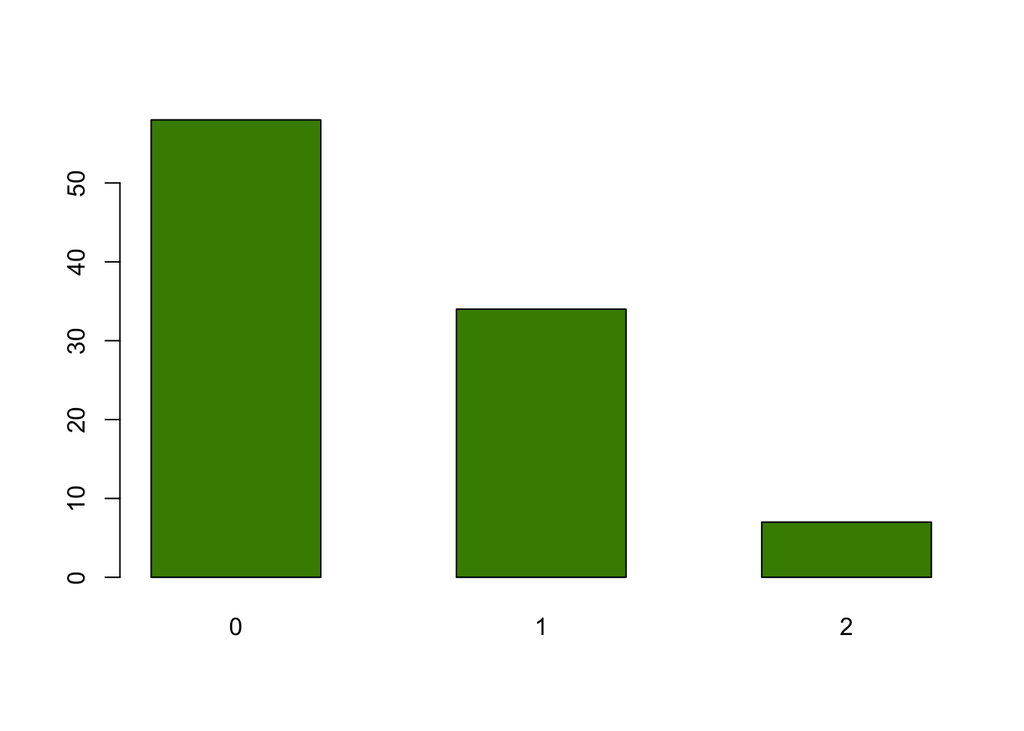

```r
barplot(table(e99), space = 0.8, col = "chartreuse4")
```

Looking at the dataset, how can we determine which theoretical distribution fits the data best?

To do this, we can use a *rootogram*, which is a visual **goodness-of-fit** diagram. If the bottom of the bars align with the horizontal axis, this means the counts correspond exactly to their theoretical values (i.e., the red points on the graph).

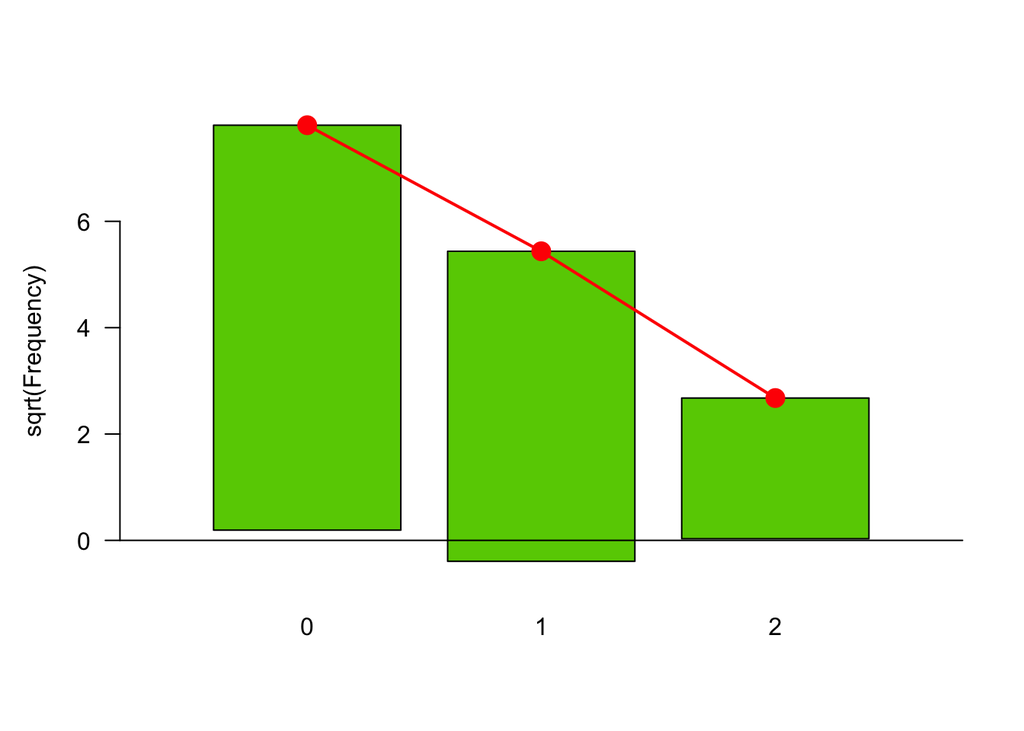

```r
gf1 = goodfit( e99, "poisson")
rootogram(gf1, xlab = "", rect_gp = gpar(fill = "chartreuse3"))
```

Based on the rootogram, does our data appear to “fit” the theoretical distribution?

Yes, the model looks like it fits the data reasonable well.

**Question 2.1** Generate 100 Poisson distributed numbers with $\lambda$ = 0.5 and generate the rootogram.

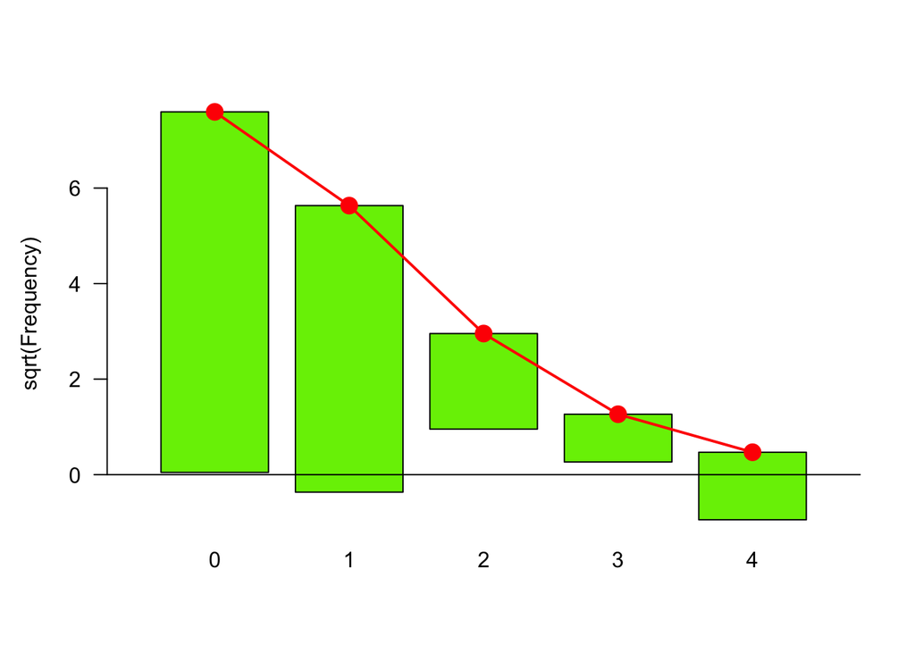

```r
set.seed(23345678)
Q2.1 <- rpois(100, 0.5)
GF2.1 = goodfit(Q2.1, "poisson")
rootogram(GF2.1, xlab = "", rect_gp = gpar(fill = "chartreuse2"))
```

Given the bars align relatively well with the horizontal axis, the Poisson model appears to fit our dataset reasonably well.

Although we may have been able to guess that the data followed a Poisson distribution based on the given parameter, $\lambda$, this may not always be the case. There may be situations where we need to use the data to estimate the parameter(s) of a distribution that would make the data most likely. These estimates are commonly denoted by Greek letters with hats on them, for example $\hat\lambda$.

To obtain this value, we can use the **maximum likelihood estimator** (MLE), which by definition, “estimates the parameters of a probability distribution by maximizing a likelihood function, so that under the assumed statistical model the observed data is most probable” [(Wikipedia)](https://en.wikipedia.org/wiki/Maximum_likelihood_estimation).

In the previous example, we had removed the extreme observation (i.e., outlier), however, in reality, we may not always know whether the data contains any outliers.

By retaining the outliers in our dataset, we are taking a conservative approach to avoid overdetection. So, if the p-value we obtain with the outlier included remains small, it is more likely that our analysis is on to something real.

### Estimating the Poisson distribution

First we tally our observations:

```r
table(e100)
```

```
## e100
##  0  1  2  7
## 58 34  7  1
```

We can input different values of $\lambda$ to see which gives us the best fit to our data above. Let’s try using a mean $\lambda$ = 3

```r
set.seed(23345678)
table(rpois(100, 3))
```

```
##
##  0  1  2  3  4  5  6  9 10
##  2 17 21 27 19  8  3  2  1
```

$\lambda$ = 3 gives us too many 2s, 3s, compared to our original dataset.

**Question 2.2** Repeat the simulation with different values of $\lambda$. Can we find one that produces counts similar to our observed data using trial and error?

```r
set.seed(23345678)
table(rpois(100, 2))
```

```
##
##  0  1  2  3  4  5  7  8
## 16 23 31 18  7  2  2  1
```

```r
table(rpois(100, 1))
```

```
##
##  0  1  2  3  4  5
## 40 30 24  4  1  1
```

```r
table(rpois(100, 4))
```

```
##
##  0  1  2  3  4  5  6  7  8  9 10
##  3  5 19 17 18 18 12  3  2  2  1
```

```r
table(rpois(100, 5))
```

```
##
##  0  1  2  3  4  5  6  7  8  9 11 12 13
##  1  6  9 15 14 24 11  8  4  3  2  2  1
```

```r
table(rpois(100, 6))
```

```
##
##  1  2  3  4  5  6  7  8  9 10 11 12 14
##  3  2  8 15 18 18 14  5  6  7  1  2  1
```

```r
table(rpois(100, 7))
```

```
##
##  2  3  4  5  6  7  8  9 10 11 12 13 14
##  3  2  7 19 10 19 11  8  6  5  5  3  2
```

None of these values appear to be a good approximation of our dataset…

Realisticaly, using trial-and-error **IS NOT** ideal, so let’s try using something more straightfoward such as an equation to estimate $\lambda$…

P(58 zeros, 34 ones, 7 twos, 1 seven | data are Poisson(*m*)) = $P(0)^{58}$ x $P(1)^{34}$ x $P(2)^{7}$ x $P(7)^{1}$

Let’s try using the above equation with *m* = 3

```r
prod(dpois(c(0, 1, 2, 7), lambda = 3) ^ (c(58, 34, 7, 1)))
```

```
## [1] 1.392143e-110
```

**Question 2.3** Compute the probabilities using the equation above for *m* = 0, 1, 2.

```r
prod(dpois(c(0, 1, 2, 7), 0) ^ (c(58, 34, 7, 1)))
```

```
## [1] 0
```

```r
prod(dpois(c(0, 1, 2, 7), 1) ^ (c(58, 34, 7, 1)))
```

```
## [1] 5.766487e-50
```

```r
prod(dpois(c(0, 1, 2, 7), 2) ^ (c(58, 34, 7, 1)))
```

```
## [1] 7.728814e-77
```

Does *m* have to be an integer? Let’s try computing the probability for *m* = 0.4.

```r
prod(dpois(c(0, 1, 2, 7), 0.4) ^ (c(58, 34, 7, 1)))
```

```
## [1] 8.5483e-46
```

Instead of working with multiplications of hundreds of small values to find the closet approximation, we can take this one step further and use something even more sophisticated such as the *log-likelihood function*.

Let’s put this into action with an example…

First, we need to generate a function that can compute the probability of the data for different values of $\lambda$.

```r
loglikelihood  =  function(lambda, data = e100) {
  sum(log(dpois(data, lambda)))
}
```

Now we can generate the log-likelihood for a series of $\lambda$ values from 0.05 to 0.95.

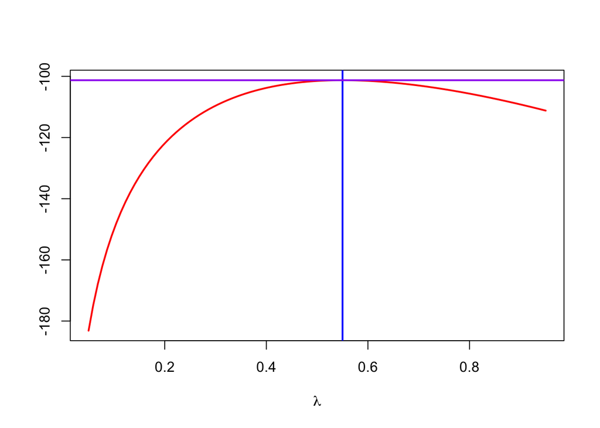

```r
lambdas = seq(0.05, 0.95, length = 100)
loglik = vapply(lambdas, loglikelihood, numeric(1))
plot(lambdas, loglik, type = "l", col = "red", ylab = "", lwd = 2,
     xlab = expression(lambda))
m0 = mean(e100)
abline(v = m0, col = "blue", lwd = 2)
abline(h = loglikelihood(m0), col = "purple", lwd = 2)
```

```r
m0
```

```
## [1] 0.55
```

The estimate of $\lambda$ = 0.55 (with the outlier included) is very close to our actual $\lambda$ = 0.5 from Chapter 1, so the Poisson distribution likely fits our data well.

**Question 2.4** What does vapply function do in the above code?

```r
?vapply #show the manual page
```

**vapply** takes the log-likelihood function (second arguement) and iteratively applies it to each of the values in the vector lambdas (first arguement) and returns a single number for each individual call to loglikelhood.

Not suprisingly, there is a shortcut to calculating the log-likelihood using the function **goodfit**

```r
gf = goodfit(e100, "poisson")
names(gf)
```

```
## [1] "observed" "count"    "fitted"   "type"     "method"   "df"
## [7] "par"
```

The output of goodfit generates a list of components, in which the *par* component contains the values of the fitted parameter(s) for the distribution studied, in this case, the estimate of $\lambda$.

```r
gf$par
```

```
## $lambda
## [1] 0.55
```

**Question 2.5** What are the other components of the output from the goodfit function?

```r
?goodfit
gf$observed
```

```
## [1] 58 34  7  0  0  0  0  1
```

```r
gf$count
```

```
## [1] 0 1 2 3 4 5 6 7
```

```r
gf$fitted
```

```
## [1] 5.769498e+01 3.173224e+01 8.726366e+00 1.599834e+00 2.199771e-01
## [6] 2.419749e-02 2.218103e-03 1.742795e-04
```

```r
gf$type
```

```
## [1] "poisson"
```

```r
gf$method
```

```
## [1] "ML"
```

```r
gf$df
```

```
## [1] 2
```

## 2.4 Applying Maximum Likelihood approaches to Binomial Data

From the first chapter, you may recall that the binomial distribution consists of two parameters; the number of trails, *n*, and the probability of seeing a “success” (or 1) in a trial. However, this probability is often unknown.

Let’s look at an example of *n* = 120 males and test them for red-green colorblindness, where 1 indicates a subject is colorblind.

```r
cb  =  c(rep(0, 110), rep(1, 10)) # create dataset of 0s and 1s
cb
```

```
##   [1] 0 0 0 0 0 0 0 0 0 0 0 0 0 0 0 0 0 0 0 0 0 0 0 0 0 0 0 0 0 0 0 0 0 0 0
##  [36] 0 0 0 0 0 0 0 0 0 0 0 0 0 0 0 0 0 0 0 0 0 0 0 0 0 0 0 0 0 0 0 0 0 0 0
##  [71] 0 0 0 0 0 0 0 0 0 0 0 0 0 0 0 0 0 0 0 0 0 0 0 0 0 0 0 0 0 0 0 0 0 0 0
## [106] 0 0 0 0 0 1 1 1 1 1 1 1 1 1 1
```

```r
table(cb) # tabulate counts
```

```
## cb
##   0   1
## 110  10
```

**Question 2.7** Which value of *p* is the most likely given these data?

$\hat{p}$ = $\frac{10}{120}$ or $\frac{1}{12}$, which also turns out to the maximum likelihood estimate.

Let’s compute the likelihood for a series of probabilities (*p*), and see where the maximum falls.

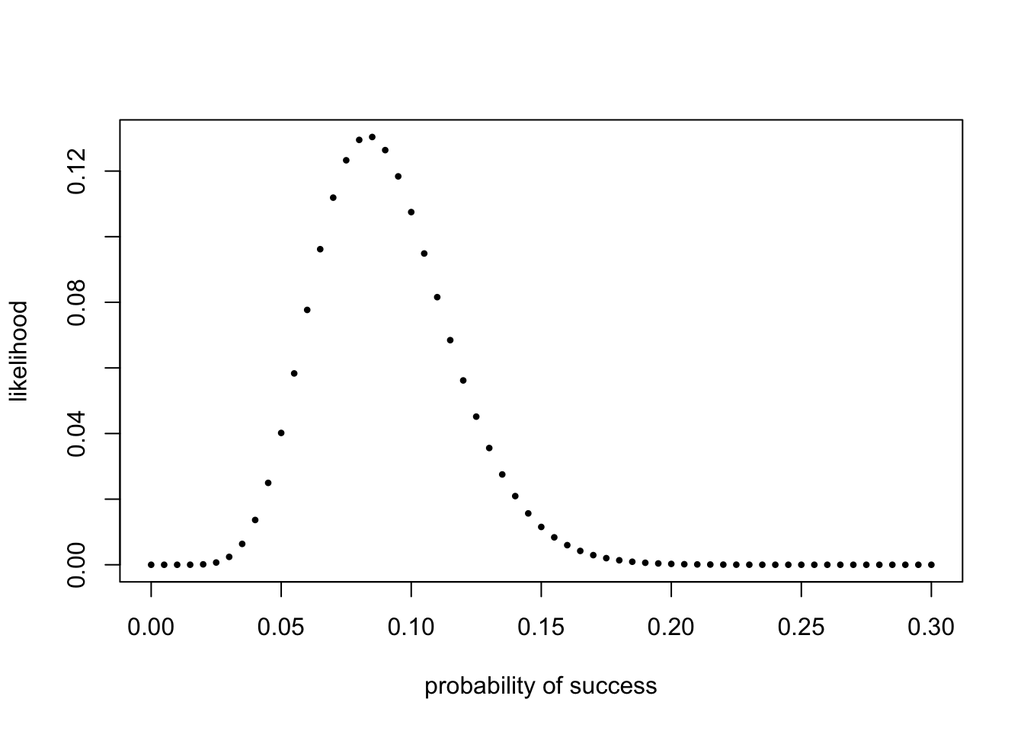

```r
probs  =  seq(0, 0.3, by = 0.005)
likelihood = dbinom(sum(cb), prob = probs, size = length(cb))
plot(probs, likelihood, pch = 16, xlab = "probability of success",
       ylab = "likelihood", cex=0.6)
```

```r
probs[which.max(likelihood)]
```

```
## [1] 0.085
```

We get 0.085, which is not exactly the value we expected ($\frac{1}{12}$), but it is very close. Since our set of probability values tested above did not contain our expected value, we essentially obtained the next best one.

## 2.5 Exploring Multinomial Data

When exploring data with more than two outcomes, we use the multinomial distribution.

Let’s explore the first gene in the *Staphyloccoccus aureus* genome and calculate the nucleotide frequencies for that gene.

```r
staph = readDNAStringSet("./data/staphsequence.ffn.txt", "fasta")
staph[1] #Explore the data contained within the first gene
```

```
##   A DNAStringSet instance of length 1
##     width seq                                          names
## [1]  1362 ATGTCGGAAAAAGAAATTTGG...AAGAAATAAGAAATGTATAA lcl|NC_002952.2_c...
```

```r
Saureus_nt = letterFrequency(staph[[1]], letters = "AGCT", OR = 0)
Saureus_nt
```

```
##   A   G   C   T
## 522 229 219 392
```

**Question 2.8** Why did we use double square brackets in the second line?

The double square brackets [[i]] extract the sequence of the ith gene as a DNAString, as opposed to the pair of single brackets [i], which return a DNAStringSet with just a single DNAString in it.

```r
length(staph[[1]])
```

```
## [1] 1362
```

```r
length(staph[1])
```

```
## [1] 1
```

```r
Saureus_nt_v2 = letterFrequency(staph[1], letters = "AGCT", OR = 0)
Saureus_nt_v2
```

```
##        A   G   C   T
## [1,] 522 229 219 392
```

It appears we do not need to include the [[]] for calculating frequencies?

**Question 2.9** Test whether the nucleotide frequencies are equally distributed across the four nucleotides for the first gene.

```r
#Observed
Sa_gene1_length <- length(staph[[1]])
Sa_gene1_freq <- Saureus_nt / Sa_gene1_length
print("Observed")
```

```
## [1] "Observed"
```

```r
Sa_gene1_freq
```

```
##         A         G         C         T
## 0.3832599 0.1681351 0.1607930 0.2878120
```

```r
#Expected
Sa_gene1_expt = rep(0.25, 4)
print("Expected")
```

```
## [1] "Expected"
```

```r
Sa_gene1_expt
```

```
## [1] 0.25 0.25 0.25 0.25
```

From the data, it appears the nulceotides are not equally distributed across gene 1.

Do the first 10 genes from these data come from the same multinomial distribution

```r
letterFrq = vapply(staph, letterFrequency, FUN.VALUE = numeric(4),
         letters = "ACGT", OR = 0)
colnames(letterFrq) = paste0("gene", seq(along = staph))
tab10 = letterFrq[, 1:10]
computeProportions = function(x) { x/sum(x) }
prop10 = apply(tab10, 2, computeProportions)
round(prop10, digits = 2)
```

```
##   gene1 gene2 gene3 gene4 gene5 gene6 gene7 gene8 gene9 gene10
## A  0.38  0.36  0.35  0.37  0.35  0.33  0.33  0.34  0.38   0.27
## C  0.16  0.16  0.13  0.15  0.15  0.15  0.16  0.16  0.14   0.16
## G  0.17  0.17  0.23  0.19  0.22  0.22  0.20  0.21  0.20   0.20
## T  0.29  0.31  0.30  0.29  0.27  0.30  0.30  0.29  0.28   0.36
```

```r
p0 = rowMeans(prop10)
p0
```

```
##         A         C         G         T
## 0.3470531 0.1518313 0.2011442 0.2999714
```

Let’s suppose p0 is the vector of the multinomial probabilities for all 10 genes and use a Monte Carlo simulation to test whether the depatures between the observed letter frequencies and expected values are within an acceptable range

First we need the genes lengths for all 10 genes.

```r
cs = colSums(tab10)
cs
```

```
##  gene1  gene2  gene3  gene4  gene5  gene6  gene7  gene8  gene9 gene10
##   1362   1134    246   1113   1932   2661    831   1515   1287    696
```

Then, we can multiply these counts with the p0 mean probabilities to get our expected counts of each nucleotide.

```r
expectedtab10 = outer(p0, cs, FUN = "*")
round(expectedtab10)
```

```
##   gene1 gene2 gene3 gene4 gene5 gene6 gene7 gene8 gene9 gene10
## A   473   394    85   386   671   924   288   526   447    242
## C   207   172    37   169   293   404   126   230   195    106
## G   274   228    49   224   389   535   167   305   259    140
## T   409   340    74   334   580   798   249   454   386    209
```

Now we create a random table with the correct column sums using the rmultinom function.

```r
randomtab10 = sapply(cs, function(s) { rmultinom(1, s, p0) } )
randomtab10
```

```
##      gene1 gene2 gene3 gene4 gene5 gene6 gene7 gene8 gene9 gene10
## [1,]   448   385    78   387   671   934   298   499   452    242
## [2,]   230   175    49   171   282   392   131   230   192     99
## [3,]   266   245    50   227   373   518   154   310   263    141
## [4,]   418   329    69   328   606   817   248   476   380    214
```

```r
all(colSums(randomtab10) == cs) #does this show that the column sums in randomtab10 are == to the column sums in cs?
```

```
## [1] TRUE
```

Repeat this simulation *B* = 1000 times. For each table, we compute the test statistic and store the results in the vector simulstat; these values constitue our NULL distribution.

```r
set.seed(234272362)
pvec = rep(1/4, 4) # We didn't previously defined pvec for this chapter; what happens when it's not defined?
stat = function(obsvd, exptd = 20 * pvec) {
   sum((obsvd - exptd)^2 / exptd)
}
B = 1000
simulstat = replicate(B, {
  randomtab10 = sapply(cs, function(s) { rmultinom(1, s, p0) })
  stat(randomtab10, expectedtab10)
})
simulstat
S1 = stat(tab10, expectedtab10)
sum(simulstat >= S1)
```

[output not shown]

Generate a histogram of simulstat. The value of S1 is marked by the vertical red line and the 0.95 and 0.99 quantiles are represented by the green and blue dotted lines, respectively.

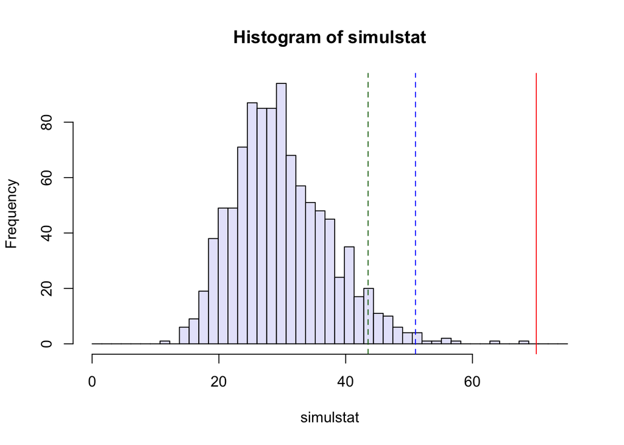

```r
hist(simulstat, col = "lavender", breaks = seq(0, 75, length.out=50))
abline(v = S1, col = "red")
abline(v = quantile(simulstat, probs = c(0.95, 0.99)),
       col = c("darkgreen", "blue"), lty = 2)
```

Based on the generated histogram, we can see that the probability of seeing a value as large as S1 = 70.1 is very small under the null model. This makes sense as seeing a value as big as S1 in our dataset after 1000 simulations was zero.

Thus, it is reasonable to conclude that the 10 genes do not seem to come from the same multinomial model.

As with all of the other long-winded exercises we have completed thus far, there is an alternative approach to reaching a similar conclusion about our dataset.

**Important Note** - Small probabilities are difficult to compute by Monte Carlo due to the granularity of the computation, which is 1/*B*. Therefore, one cannot estimate probabilites smaller than that.

## 2.6 Chi-squared ($\chi^2$) Distribution

Two types of $\chi^2$ tests

$\chi^2$ Goodness of Fit - Determine whether the sample data matches the population

$\chi^2$ Test for Independence - Compare two categorical variables (in a contingency table) to see if they are related.

Degree’s of Freedom (df) - Number of categories - 1

When comparing two distributions, either from two different samples or from a single sampe and a theoretical model, looking at the historgrams is not always as informative as we’d like.

To check how well theory and simulation correspond to one another, we can use another goodness-of-fit-tool known as the **quantile-quantile (QQ) plot**.

**Question 2.10**

(a)Compare the simulstat values and 1000 randomly generated $\chi^2_{30}$ random numbers by displaying them in histograms with 50 bins each.

How do we do this?

(b)Compute the quantiles of the simulstat values and compare them to those of the $\chi^2_{30}$ distribution

Check the manual pages for quantile

```r
?quantile
```

The type arguement in quantile, which can be an integer between 1 and 9, reflects the type of quantile algorithm to be used.

```r
qs = ppoints(100)
?ppoints # Generates a sequence of probability points, where n = the numer of points
qs
```

```
##   [1] 0.005 0.015 0.025 0.035 0.045 0.055 0.065 0.075 0.085 0.095 0.105
##  [12] 0.115 0.125 0.135 0.145 0.155 0.165 0.175 0.185 0.195 0.205 0.215
##  [23] 0.225 0.235 0.245 0.255 0.265 0.275 0.285 0.295 0.305 0.315 0.325
##  [34] 0.335 0.345 0.355 0.365 0.375 0.385 0.395 0.405 0.415 0.425 0.435
##  [45] 0.445 0.455 0.465 0.475 0.485 0.495 0.505 0.515 0.525 0.535 0.545
##  [56] 0.555 0.565 0.575 0.585 0.595 0.605 0.615 0.625 0.635 0.645 0.655
##  [67] 0.665 0.675 0.685 0.695 0.705 0.715 0.725 0.735 0.745 0.755 0.765
##  [78] 0.775 0.785 0.795 0.805 0.815 0.825 0.835 0.845 0.855 0.865 0.875
##  [89] 0.885 0.895 0.905 0.915 0.925 0.935 0.945 0.955 0.965 0.975 0.985
## [100] 0.995
```

```r
quantile(simulstat, qs)
```

```
##     0.5%     1.5%     2.5%     3.5%     4.5%     5.5%     6.5%     7.5%
## 15.16774 16.74523 17.36799 18.41902 18.74366 19.31480 19.56842 20.04756
##     8.5%     9.5%    10.5%    11.5%    12.5%    13.5%    14.5%    15.5%
## 20.32303 20.55447 20.78786 21.09210 21.69742 21.97236 22.24843 22.64804
##    16.5%    17.5%    18.5%    19.5%    20.5%    21.5%    22.5%    23.5%
## 22.85891 23.09560 23.48028 23.71125 23.86817 24.04972 24.20378 24.37875
##    24.5%    25.5%    26.5%    27.5%    28.5%    29.5%    30.5%    31.5%
## 24.56856 24.67012 24.99593 25.12356 25.25721 25.47174 25.63252 25.81733
##    32.5%    33.5%    34.5%    35.5%    36.5%    37.5%    38.5%    39.5%
## 25.93613 26.14100 26.29829 26.44720 26.68950 26.90893 27.04738 27.26378
##    40.5%    41.5%    42.5%    43.5%    44.5%    45.5%    46.5%    47.5%
## 27.39029 27.57109 27.79237 27.98326 28.23572 28.40953 28.61686 28.67754
##    48.5%    49.5%    50.5%    51.5%    52.5%    53.5%    54.5%    55.5%
## 28.85158 29.01151 29.14663 29.29161 29.50829 29.62587 29.79492 29.90889
##    56.5%    57.5%    58.5%    59.5%    60.5%    61.5%    62.5%    63.5%
## 30.10701 30.32608 30.42109 30.64050 30.84450 31.06417 31.25753 31.58344
##    64.5%    65.5%    66.5%    67.5%    68.5%    69.5%    70.5%    71.5%
## 31.85270 32.00596 32.32156 32.44542 32.67528 33.07777 33.26213 33.59003
##    72.5%    73.5%    74.5%    75.5%    76.5%    77.5%    78.5%    79.5%
## 33.77463 34.13126 34.29629 34.79229 35.07257 35.50881 35.63698 36.11505
##    80.5%    81.5%    82.5%    83.5%    84.5%    85.5%    86.5%    87.5%
## 36.37213 36.60503 36.97795 37.31318 37.55610 37.85453 38.34154 38.83312
##    88.5%    89.5%    90.5%    91.5%    92.5%    93.5%    94.5%    95.5%
## 39.56357 40.13470 40.55812 41.14004 41.56840 42.17993 43.21938 44.02803
##    96.5%    97.5%    98.5%    99.5%
## 45.22576 46.77486 48.75071 54.84348
```

```r
quantile(qchisq(qs, df = 30), qs)
```

```
##     0.5%     1.5%     2.5%     3.5%     4.5%     5.5%     6.5%     7.5%
## 14.74308 16.23869 17.16382 17.87179 18.45879 18.96730 19.42030 19.83175
##     8.5%     9.5%    10.5%    11.5%    12.5%    13.5%    14.5%    15.5%
## 20.21086 20.56401 20.89588 21.20996 21.50896 21.79501 22.06984 22.33486
##    16.5%    17.5%    18.5%    19.5%    20.5%    21.5%    22.5%    23.5%
## 22.59125 22.83999 23.08192 23.31776 23.54813 23.77359 23.99461 24.21163
##    24.5%    25.5%    26.5%    27.5%    28.5%    29.5%    30.5%    31.5%
## 24.42502 24.63512 24.84224 25.04668 25.24867 25.44846 25.64627 25.84230
##    32.5%    33.5%    34.5%    35.5%    36.5%    37.5%    38.5%    39.5%
## 26.03673 26.22975 26.42152 26.61219 26.80192 26.99084 27.17910 27.36683
##    40.5%    41.5%    42.5%    43.5%    44.5%    45.5%    46.5%    47.5%
## 27.55414 27.74118 27.92804 28.11486 28.30175 28.48883 28.67621 28.86400
##    48.5%    49.5%    50.5%    51.5%    52.5%    53.5%    54.5%    55.5%
## 29.05231 29.24127 29.43100 29.62161 29.81322 30.00595 30.19994 30.39530
##    56.5%    57.5%    58.5%    59.5%    60.5%    61.5%    62.5%    63.5%
## 30.59219 30.79073 30.99107 31.19337 31.39779 31.60450 31.81367 32.02550
##    64.5%    65.5%    66.5%    67.5%    68.5%    69.5%    70.5%    71.5%
## 32.24019 32.45796 32.67904 32.90367 33.13213 33.36471 33.60172 33.84351
##    72.5%    73.5%    74.5%    75.5%    76.5%    77.5%    78.5%    79.5%
## 34.09046 34.34299 34.60155 34.86665 35.13886 35.41883 35.70725 36.00496
##    80.5%    81.5%    82.5%    83.5%    84.5%    85.5%    86.5%    87.5%
## 36.31286 36.63203 36.96368 37.30925 37.67041 38.04916 38.44789 38.86951
##    88.5%    89.5%    90.5%    91.5%    92.5%    93.5%    94.5%    95.5%
## 39.31761 39.79669 40.31253 40.87266 41.48728 42.17057 42.94329 43.83752
##    96.5%    97.5%    98.5%    99.5%
## 44.90723 46.25504 48.12235 51.45778
```

Generate a QQ plot to display the theoretical quantiles for the $\chi^2_{30}$ distribution on the x-axis and the simulated ones on the vertical axis.

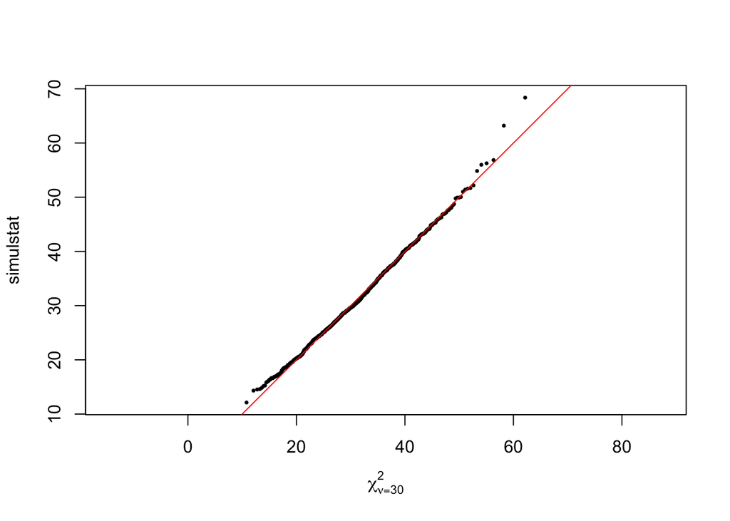

```r
qqplot(qchisq(ppoints(B), df = 30), simulstat, main = "",
  xlab = expression(chi[nu==30]^2), asp = 1, cex = 0.5, pch = 16)
abline(a = 0, b = 1, col = "red")
```

```r
#If asp is removed, it will changed the aspect ratio, meaning both the X and Y axes will start at 10
```

Now that we are confident that simulstat is well described by a $\chi^2_{30}$ distribution, we can compute our p-value, which is the probability under the null hypothesis that we observe a value as high as S1 = 70.1.

Important Note: The p-value is NOT the probability that any particular hypothesis is true or falase, rather it is the probability of obtaining the *sample result* IF the NULL hypothesis were true.

```r
1 - pchisq(S1, df = 30)
```

```
## [1] 4.74342e-05
```

If the null hypothesis were true, we would observe a value as high at S1 = 70.1 ~0.004% of the time, making the NULL hypothesis highly improbable.

## 2.7 Chargaff’s Rule

What is it?

Explains the principle of base pairing in DNA.

“Chargaff’s rules state that DNA from any cell of any organisms should have a 1:1 ratio of pyrimidine and purine bases and, more specifically, that the amount of guanine (G) should be equal to cytosine (C) and the amount of adenine (A) should be equal to thymine (T)” [https://en.wikipedia.org/wiki/Chargaff%27s_rules].

However, the amount of G/C and A/T is highly variable among different organisms with no obvious pattern.

Based on Chargaff’s Rule, A = T and G = C

```r
load("./data/ChargaffTable.RData")
ChargaffTable
```

```
##                   A    T    C    G
## Human-Thymus   30.9 29.4 19.9 19.8
## Mycobac.Tuber  15.1 14.6 34.9 35.4
## Chicken-Eryth. 28.8 29.2 20.5 21.5
## Sheep-liver    29.3 29.3 20.5 20.7
## Sea Urchin     32.8 32.1 17.7 17.3
## Wheat          27.3 27.1 22.7 22.8
## Yeast          31.3 32.9 18.7 17.1
## E.coli         24.7 23.6 26.0 25.7
```

We are going to look at a comparison between the data and what would occur if the nucleotides were “exchangeable”, meaning there is no particular relationship between the proportion of As and Ts or Gs and Cs.

*Formula* $(p_C - p_G)^2 + (p_A - p_T)^2$

```r
statChf = function(x){
  sum((x[, "C"] - x[, "G"])^2 + (x[, "A"] - x[, "T"])^2)
}
chfstat = statChf(ChargaffTable)
chfstat # Observed value
```

```
## [1] 11.08
```

```r
permstat = replicate(100000, {
     permuted = t(apply(ChargaffTable, 1, sample))
     colnames(permuted) = colnames(ChargaffTable)
     statChf(permuted)
})
pChf = mean(permstat <= chfstat)
pChf
```

```
## [1] 0.00014
```

Generate a histogram of permstat

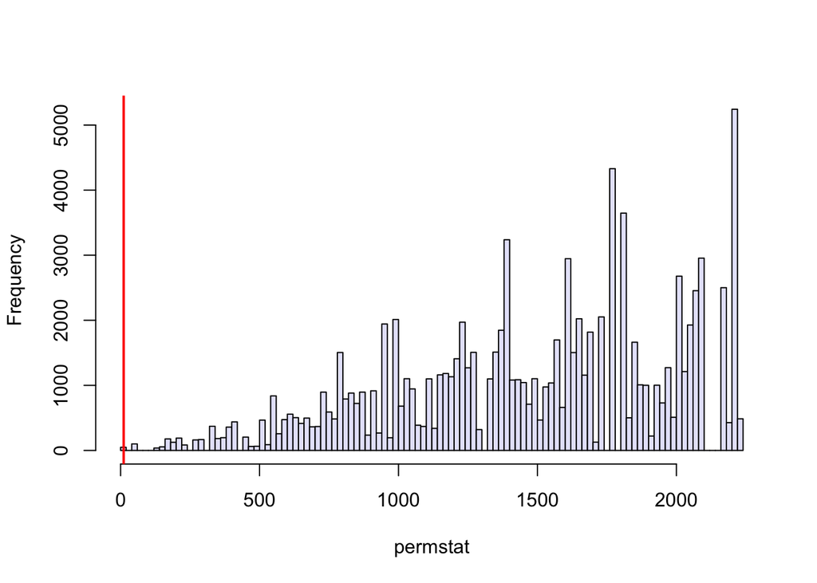

```r
hist(permstat, breaks = 100, main = "", col = "lavender")
abline(v = chfstat, lwd = 2, col = "red")
```

**Question 2.14** Why did we only look at the values in the null distribution smaller that the observed value?

### 2.7.1 Two categorical variables

Prior to this point, we have looked at situations were the data are classified into one of two boxes - Binomial - Yes/ No - Multinomial - Nucleotides (A, T, G, C) - Genotypes (AA, aa, Aa)

We can also measure two (or more) categorial variables on a set of subjects, for example, eye color and hair color. This is typically achieved using a table of cross counts known as a *contingency table*.

```r
HairEyeColor
```

```
## , , Sex = Male
##
##        Eye
## Hair    Brown Blue Hazel Green
##   Black    32   11    10     3
##   Brown    53   50    25    15
##   Red      10   10     7     7
##   Blond     3   30     5     8
##
## , , Sex = Female
##
##        Eye
## Hair    Brown Blue Hazel Green
##   Black    36    9     5     2
##   Brown    66   34    29    14
##   Red      16    7     7     7
##   Blond     4   64     5     8
```

```r
HairEyeColor[,, "Female"]
```

```
##        Eye
## Hair    Brown Blue Hazel Green
##   Black    36    9     5     2
##   Brown    66   34    29    14
##   Red      16    7     7     7
##   Blond     4   64     5     8
```

```r
HairEyeColor[,, "Male"]
```

```
##        Eye
## Hair    Brown Blue Hazel Green
##   Black    32   11    10     3
##   Brown    53   50    25    15
##   Red      10   10     7     7
##   Blond     3   30     5     8
```

Question 2.15 Explore the HairEyeColor object

```r
str(HairEyeColor)
```

```
##  'table' num [1:4, 1:4, 1:2] 32 53 10 3 11 50 10 30 10 25 ...
##  - attr(*, "dimnames")=List of 3
##   ..$ Hair: chr [1:4] "Black" "Brown" "Red" "Blond"
##   ..$ Eye : chr [1:4] "Brown" "Blue" "Hazel" "Green"
##   ..$ Sex : chr [1:2] "Male" "Female"
```

Color Blindness and Sex

Is there a relationship between sex and the occurrence of color blindness?

$H_0$: No relationship between sex and color blindness $H_A$: There is a relationship between sex and color blindness

```r
load("./data/Deuteranopia.RData")
Deuteranopia
```

```
##           Men Women
## Deute      19     2
## NonDeute 1981  1998
```

We can use the $\chi^2$ test to test our hypothesis

```r
chisq.test(Deuteranopia)
```

```
##
##  Pearson's Chi-squared test with Yates' continuity correction
##
## data:  Deuteranopia
## X-squared = 12.255, df = 1, p-value = 0.0004641
```

Given our p-value is < 0.05 ($\alpha$), we can reject $H_0$ as there appears to be a relationship among sex and color blindess.

### 2.7.2 Hardy-Weinberg – Special Multinomial

*Hardy-Weinberg Principle* In the absence of evolution, allele and genotype frequencies in a population will remain constant.

Recall that *p* + *q* = 1, where p is the frequency of the dominant allele and q is the frequency of the recessive allele

AND

Therefore,

$p^2$ + 2*pq* + $q^2$ = 1

```r
data("Mourant")
str(Mourant)
```

```
## 'data.frame':    216 obs. of  6 variables:
##  $ Population: Factor w/ 9 levels "Africa","America",..: 9 4 4 4 4 6 5 5 5 5 ...
##  $ Country   : Factor w/ 56 levels "Alaska","Australia",..: 41 1 20 20 20 56 3 3 3 3 ...
##  $ Total     : int  5728 604 2081 569 739 500 2000 6557 3000 10000 ...
##  $ MM        : int  1743 386 1160 475 646 285 610 2185 914 3156 ...
##  $ MN        : int  3222 184 780 89 90 186 1018 2993 1548 4761 ...
##  $ NN        : int  763 34 141 5 3 29 372 1379 538 2083 ...
```

```r
Mourant[214:216,]
```

```
##     Population    Country Total  MM  MN  NN
## 214    Oceania Micronesia   962 228 436 298
## 215    Oceania Micronesia   678  36 229 413
## 216    Oceania     Tahiti   580 188 296  96
```

Plot the log-likelihood for the Tahiti data…

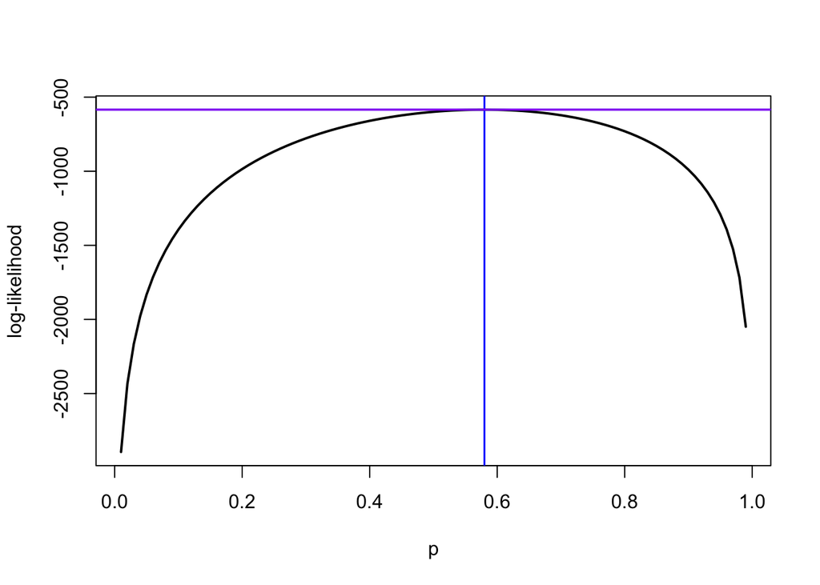

```r
nMM = Mourant$MM[216]
nMN = Mourant$MN[216]
nNN = Mourant$NN[216]
loglik = function(p, q = 1 - p) {
  2 * nMM * log(p) + nMN * log(2*p*q) + 2 * nNN * log(q)
}
xv = seq(0.01, 0.99, by = 0.01)
yv = loglik(xv)
plot(x = xv, y = yv, type = "l", lwd = 2,
     xlab = "p", ylab = "log-likelihood")
imax = which.max(yv)
?abline
abline(v = xv[imax], h = yv[imax], lwd = 1.5, col = "blue") # draws both lines
abline(h = yv[imax], lwd = 1.5, col = "purple") # changes color of horizontal line
```

```r
phat  =  af(c(nMM, nMN, nNN))
phat
```

```
## [1] 0.5793103
```

```r
pMM   =  phat^2
pMM
```

```
## [1] 0.3356005
```

```r
qhat  =  1 - phat
qhat
```

```
## [1] 0.4206897
```

Calculate the expected values under the Hardy-Weinberg equilibrium

```r
pHW = c(MM = phat^2, MN = 2*phat*qhat, NN = qhat^2)
sum(c(nMM, nMN, nNN)) * pHW
```

```
##       MM       MN       NN
## 194.6483 282.7034 102.6483
```

Comparing the expected values to our observed values, they are quite similar.

A visual evaluation of the goodness-of-fit of Hardy-Weinberg can be called using HWTernaryPlot.

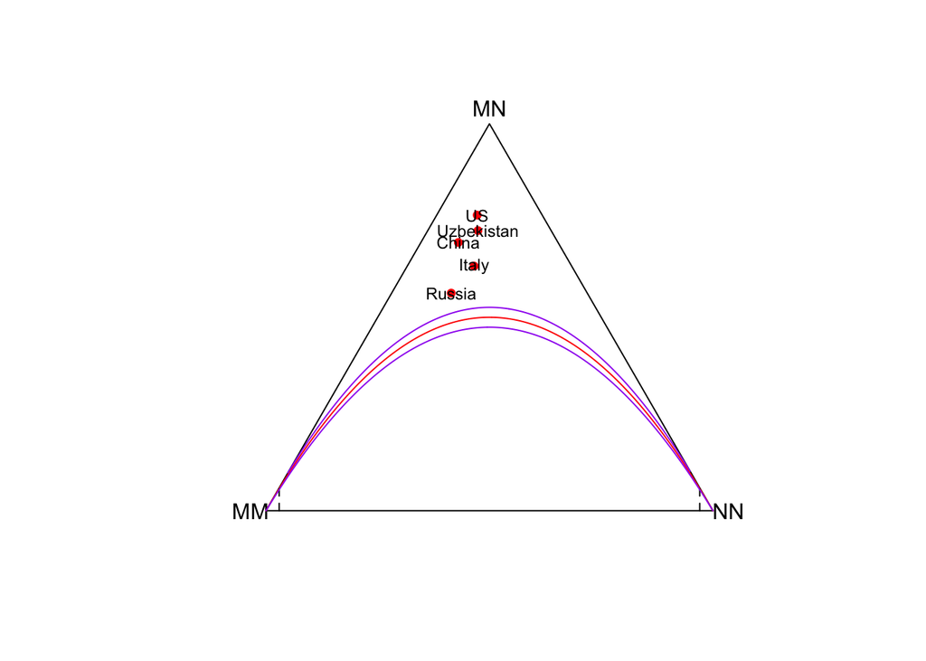

```r
pops = c(1, 69, 128, 148, 192)
genotypeFrequencies = as.matrix(Mourant[, c("MM", "MN", "NN")])
HWTernaryPlot(genotypeFrequencies[pops, ],
        markerlab = Mourant$Country[pops],
        alpha = 0.0001, curvecols = c("red", rep("purple", 4)),
        mcex = 0.75, vertex.cex = 1)
```

In the figure generated above, the Hardy-Weinberg model is the red curve, and the region where we cannot reject the model exists between the two purple lines.

**Question 2.16** Add the other data points to the ternary plot and back up your discussion using the HWChisq function

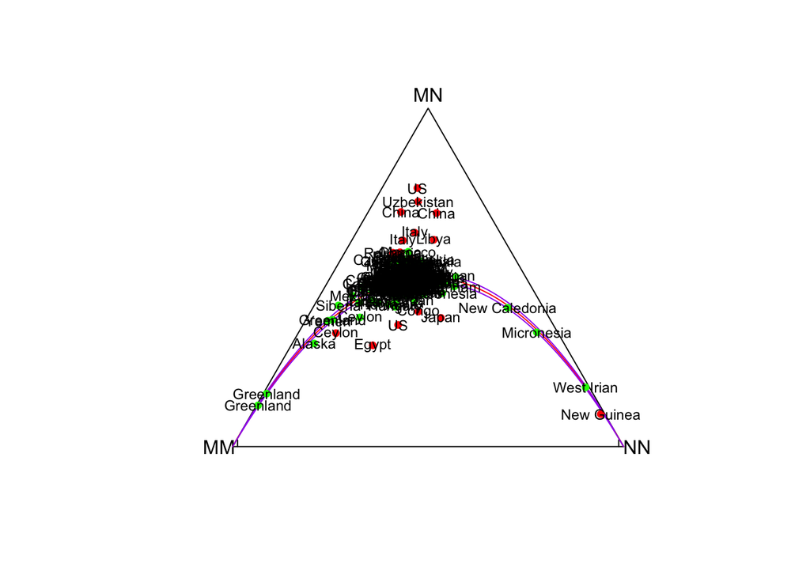

```r
pops = c(1:216)
genotypeFrequencies = as.matrix(Mourant[, c("MM", "MN", "NN")])
HWTernaryPlot(genotypeFrequencies[pops, ],
        markerlab = Mourant$Country[pops],
        alpha = 0.0001, curvecols = c("red", rep("purple", 4)),
        mcex = 0.75, vertex.cex = 1)
```

```r
?HWChisq()
HWChisqMat(genotypeFrequencies) %>% table()
```

[output not shown]

**Question 2.17** Divide all the total frequencies by 50 and recreate the ternary plot

```r
newgf = round(genotypeFrequencies / 50)
newgf %>%  as_tibble %>% print(n=20)
```

```
## # A tibble: 216 x 3
##       MM    MN    NN
##    <dbl> <dbl> <dbl>
##  1    35    64    15
##  2     8     4     1
##  3    23    16     3
##  4    10     2     0
##  5    13     2     0
##  6     6     4     1
##  7    12    20     7
##  8    44    60    28
##  9    18    31    11
## 10    63    95    42
## 11    12    19     8
## 12    18    31    13
## 13     6    10     4
## 14     4     7     2
## 15    23    40    17
## 16     3     5     2
## 17     8    11     4
## 18    29    56    17
## 19    12    20     9
## 20    30    52    22
## # … with 196 more rows
```

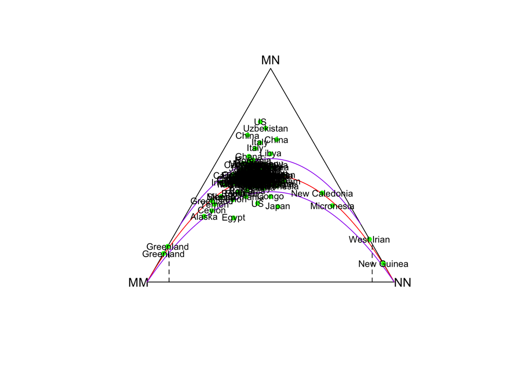

```r
HWTernaryPlot(newgf[pops, ],
        markerlab = Mourant$Country[pops],
        alpha = 0.0001, curvecols = c("red", rep("purple", 4)),
        mcex = 0.75, vertex.cex = 1)
```

(a) What happens to the points?

- Majority of the points are now green; this means that these points are not significant markers (according to the $\chi^2$ test)
2. What happens to the confidence regions and why?
- The confidence regions become larger; become less sure in rejecting the Hardy-Weinberg model.

### 2.7.3 Sequence Motifs and Logos

Let’s look at the *Kozak motif*, which is a sequence that occurs close to the start codon ATG of a coding region. Unlike the fixed spelling of the start codon, the nucleotides to the left of motif can be highly variable.

To determine the multinomial probabilites at each position, we can use the position weight matrix (PWM) or position-specific scoring matrix (PSSM) and then visualize it graphically using the sequence logo.

```r
load("./data/kozak.RData")
kozak
```

```
##   [,1] [,2] [,3] [,4] [,5] [,6] [,7] [,8] [,9]
## A 0.33 0.25  0.4 0.15 0.20    1    0    0 0.05
## C 0.12 0.25  0.1 0.40 0.40    0    0    0 0.05
## G 0.33 0.25  0.4 0.20 0.25    0    0    1 0.90
## T 0.22 0.25  0.1 0.25 0.15    0    1    0 0.00
```

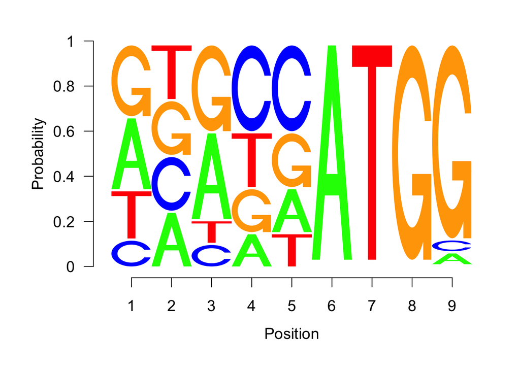

```r
pwm = makePWM(kozak)
seqLogo(pwm, ic.scale = FALSE)
```

## 2.8 Markov Chains

Markov Chains - System that experiances transitions from one state to another according to certain probabilistic rules - Only knowledge of the previous state is necessary to deteremine the probability distribution of the current state.

## 2.9 Bayesian Thinking

Uses prior knowledge to initially estimate the probability of an event before any data is collected (i.e., prior probability) and then uses the collected data to determine the probability of the event given the observed data. Depending on the data, this estimate, otherwise known as the posterior probability, may be higher or lower than our prior probability.

Unlike other approaches, Bayesian statistics allow us to **update** or **shift** our knowledge of our parameters as new information is attained.

Of note, as long as there is enough data, the choice of the prior probability has little effect on the result.

### Haplotypes

A haplotype is a collection of alleles that are genetically linked, meaning there are inherited together.

In this section we are going to explore haplotype frequencies, specifically, the proportion of a particular Y-haplotype that contains a set of different short tandem repeats.

```r
hap6 = read.table("./data/haplotype6.txt", header = TRUE, sep = "", dec = ".")
hap6
```

```
##   Individual DYS19 DXYS156Y DYS389m DYS389n DYS389p
## 1         H1    14       12       4      12       3
## 2         H3    15       13       4      13       3
## 3         H4    15       11       5      11       3
## 4         H5    17       13       4      11       3
## 5         H7    13       12       5      12       3
## 6         H8    16       11       5      12       3
```

Our task is to find the proportion, $\theta$, of the haplotype of interest, in the population of interest, where the occurrence of a haplotype is considered a “success”.

### 2.9.2 Simulation

When we are looking at a parameter that is a proportion or probability between 0 and 1, it is convenient to use the *beta distribution*. If our prior is the belief that theta is beta and observe data in the form of n binomial trials, then our posterior theta have an updated beta distribution.

The distribution of Y due to a different distribution of theta is known as the *marginal distribution* of Y

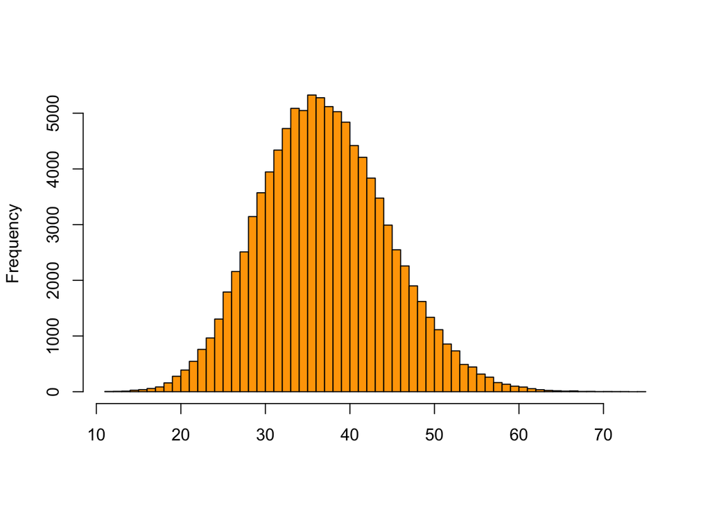

```r
rtheta = rbeta(100000, 50, 350)
y = vapply(rtheta, function(th) {
  rbinom(1, prob=th, size=300)
}, numeric(1))
hist(y, breaks =50, col ="orange", main= "", xlab = "")
```

**Question 2.18** Verify we can get the same result as the above code chunk by using R’s vectorization capabilities

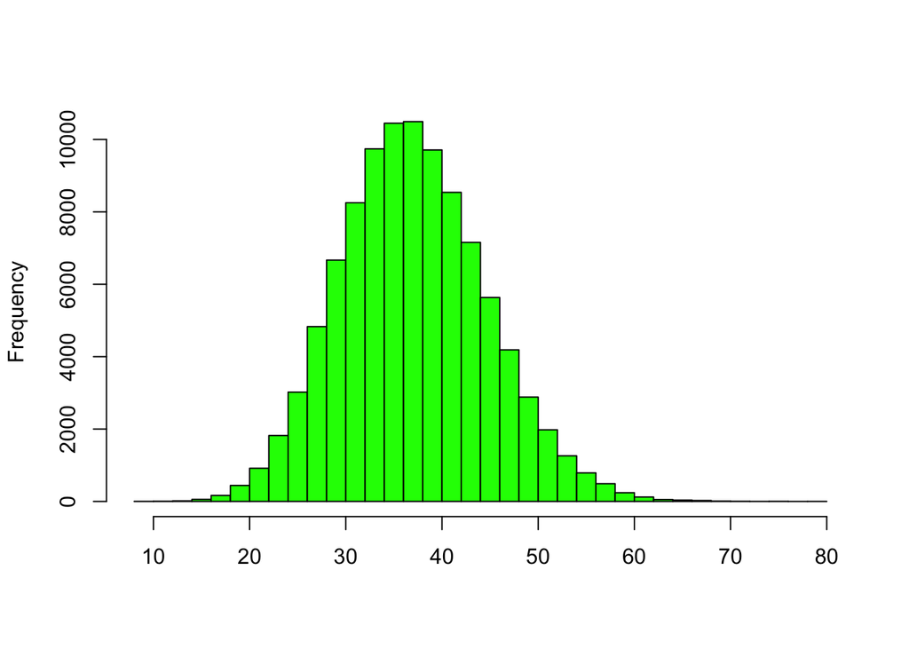

```r
set.seed(2723473)
Q2.18 = rbinom(length(rtheta), rtheta, size = 300)
hist(Q2.18, breaks = 50, col = "green", main = "", xlab = "")
```

We can calculate the posterior distribution of $\theta$ by conditioning on outcomes where *Y* is 40, and then compare it to the theoretical posterior, densPostTheory.

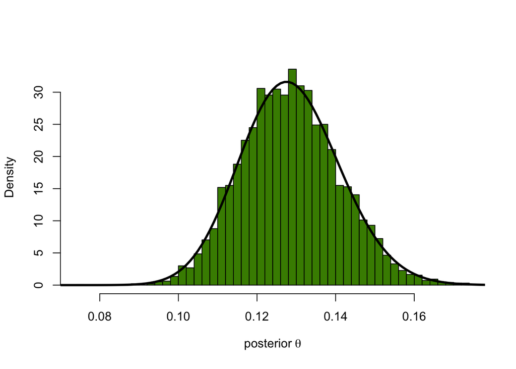

```r
thetas = seq(0, 1, by = 0.001) # vector from pg. 26
thetaPostEmp = rtheta[ y == 40 ]
hist(thetaPostEmp, breaks = 40, col = "chartreuse4", main = "",
  probability = TRUE, xlab = expression("posterior"~theta))
densPostTheory  =  dbeta(thetas, 90, 610)
lines(thetas, densPostTheory, type="l", lwd = 3)
```

The histogram shows the simulated values for the posterior distribution of $\theta$, while the line corresponds to the theoretical density of a beta distribution with the theoretical posterior parameters.

Calculate the means of both distributions.

```r
mean(thetaPostEmp)
```

```
## [1] 0.1285505
```

```r
dtheta = thetas[2]-thetas[1]
sum(thetas * densPostTheory * dtheta)
```

```
## [1] 0.1285714
```

We can use Monte Carlo Integration to compute the posterior mean.

```r
thetaPostMC = rbeta(n=1e6, 90, 610)
mean(thetaPostMC)
```

```
## [1] 0.1285536
```

Let’s check the concordance between the Monte Carlo sample and our sample using a QQ-plot.

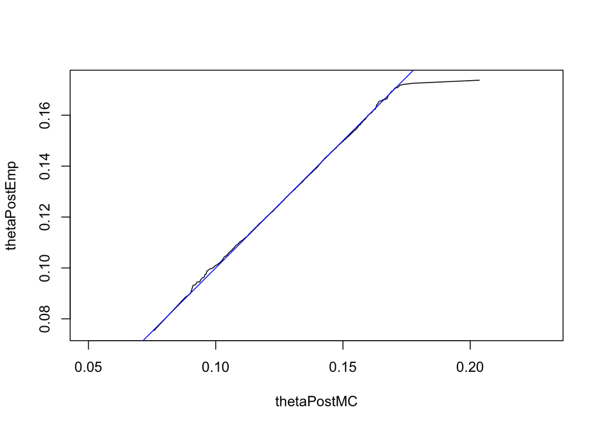

```r
qqplot(thetaPostMC, thetaPostEmp, type = "l", asp =1)
abline(a =0, b=1, col="blue")
```

Since the curve lies on *y = x*, this indicates good agreement between the two distributions, which suggests that the posterior distribution is also a beta distribution…

The slight variablity in the means for each of the distributions is likely attributed to the random differences at the tails.

We can use the following formula to estimate $\theta$ with the uncertainty given by the posterior distribution

beta(90, 610) = beta($\alpha$ + *y*, $\beta$ + (n - *y*))

Where *y* = the observed successes and *n-y* = the observed failures

Now we will collect a new set of data with *n* = 150 observations and *y* = 25 successes for beta(90, 610)

```r
alpha = 90
beta = 610
success = 25
fail = 150 - success
fail
```

```
## [1] 125
```

```r
num = sum(alpha, success)
num
```

```
## [1] 115
```

```r
theta = num / sum(num, beta, fail) # mean of the distribution
theta
```

```
## [1] 0.1352941
```

We can also use the **maximum a posteriori (MAP) estimate** to deteremine the value that maximizes the posterior distribution with a single estimate

```r
densPost2 = dbeta(thetas, 115, 735)
mcPost2 = rbeta(1e6, 115, 735)
sum(thetas * densPost2 * dtheta) # mean, by numeric integration
```

```
## [1] 0.1352941
```

```r
mean(mcPost2) # mean, by Monte Carlo
```

```
## [1] 0.1352972
```

```r
thetas[which.max(densPost2)] # MAP estimate
```

```
## [1] 0.134
```

**Question 2.20** Make a histogram of the distribution …Not quite sure how to do this…

Confidence for the proportion parameter

```r
quantile(mcPost2, c(0.025, 0.975))
```

```
##      2.5%     97.5%
## 0.1131596 0.1590618
```

## 2.10 Nucleotide Patterns

*Biostrings* package provides tools for working with sequence data, with the essential *classes* *DNAString* and *DNAStringSet*, which allows us to work with one or multiple DNA sequences, respectively.

**Question 2.21** Explore the *BioStrings* package using the vignette command

```r
vignette(package = "Biostrings") # View a list of the manuals in the package
vignette("BiostringsQuickOverview", package = "Biostrings") # Opens the BiostringsQuickOverview in a separate window
```

Another useful package is *BSgenome*, which as the name would imply, provides access to many genomes.

```r
available.genomes() #View the genomes available in the package
```

```
##  [1] "BSgenome.Alyrata.JGI.v1"
##  [2] "BSgenome.Amellifera.BeeBase.assembly4"
##  [3] "BSgenome.Amellifera.UCSC.apiMel2"
##  [4] "BSgenome.Amellifera.UCSC.apiMel2.masked"
##  [5] "BSgenome.Aofficinalis.NCBI.V1"
##  [6] "BSgenome.Athaliana.TAIR.04232008"
##  [7] "BSgenome.Athaliana.TAIR.TAIR9"
##  [8] "BSgenome.Btaurus.UCSC.bosTau3"
##  [9] "BSgenome.Btaurus.UCSC.bosTau3.masked"
## [10] "BSgenome.Btaurus.UCSC.bosTau4"
## [11] "BSgenome.Btaurus.UCSC.bosTau4.masked"
## [12] "BSgenome.Btaurus.UCSC.bosTau6"
## [13] "BSgenome.Btaurus.UCSC.bosTau6.masked"
## [14] "BSgenome.Btaurus.UCSC.bosTau8"
## [15] "BSgenome.Carietinum.NCBI.v1"
```

[output cut: 78 more lines]

Let’s explore the occurance of the Shine-Dalgarno (SD) sequence AGGAGGT motif, which initiates protein synthesis in prokaryotes, in *Escherichia coli* K12-DH10B

```r
Ecoli
```

```
## E. coli genome:
## # organism: Escherichia coli (E. coli)
## # provider: NCBI
## # provider version: 2008/08/05
## # release date: NA
## # release name: NA
## # 13 sequences:
## #   NC_008253 NC_008563 NC_010468 NC_004431 NC_009801 NC_009800 NC_002655
## #   NC_002695 NC_010498 NC_007946 NC_010473 NC_000913 AC_000091
## # (use 'seqnames()' to see all the sequence names, use the '$' or '[['
## # operator to access a given sequence)
```

```r
shineDalgarno = "AGGAGGT"
ecoli = Ecoli$NC_010473
length(Ecoli$NC_010473)
```

```
## [1] 4686137
```

We can count the number of SD instances in windows of 50000 bp using countPattern.

```r
window = 50000
starts = seq(1, length(ecoli) - window, by = window)
ends = starts + window - 1
numMatches = vapply(seq_along(starts), function(i){
  countPattern(shineDalgarno, ecoli[starts[i]:ends[i]], max.mismatch=0)
}, numeric(1))
table(numMatches)
```

```
## numMatches
##  0  1  2  3  4
## 48 32  8  3  2
```

```r
numMatches
```

```
##  [1] 0 1 0 1 4 0 0 0 1 0 0 1 0 0 1 0 0 0 0 3 0 0 4 0 1 0 2 2 1 0 1 0 1 1 1
## [36] 0 0 0 0 1 3 1 1 1 1 0 0 0 0 1 0 0 1 0 2 1 2 1 1 0 0 0 0 0 1 0 1 1 0 1
## [71] 2 0 0 0 0 0 0 0 0 1 1 0 3 1 0 1 2 1 2 1 2 0 1
```

The data generated above most likely follows a Poisson distribution.

```r
gf = goodfit(numMatches, "poisson")
summary(gf)
```

```
##
##   Goodness-of-fit test for poisson distribution
##
##                       X^2 df  P(> X^2)
## Likelihood Ratio 4.134932  3 0.2472577
```

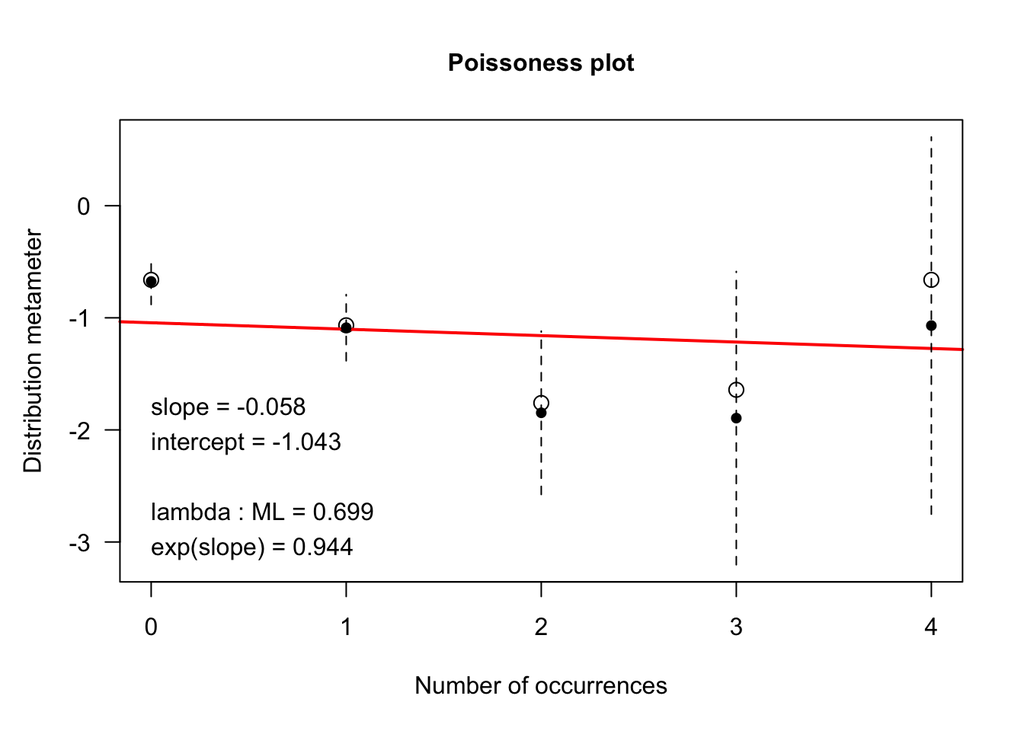

```r
distplot(numMatches, type="poisson")
```

The matches can be explored using matchPattern

```r
sdMatches = matchPattern(shineDalgarno, ecoli, max.mismatch = 0)
sdMatches
```

```
##   Views on a 4686137-letter DNAString subject
## subject: AGCTTTTCATTCTGACTGCAACGGGCAATATG...CAAATAAAAAACGCCTTAGTAAGTATTTTTC
## views:
##        start     end width
##  [1]   56593   56599     7 [AGGAGGT]
##  [2]  199644  199650     7 [AGGAGGT]
##  [3]  202176  202182     7 [AGGAGGT]
##  [4]  214433  214439     7 [AGGAGGT]
##  [5]  217429  217435     7 [AGGAGGT]
##  ...     ...     ...   ... ...
## [61] 4438786 4438792     7 [AGGAGGT]
## [62] 4498085 4498091     7 [AGGAGGT]
## [63] 4536658 4536664     7 [AGGAGGT]
## [64] 4546821 4546827     7 [AGGAGGT]
## [65] 4611626 4611632     7 [AGGAGGT]
```

The data above displays the locations for all instances of the SD in the K12 genome.

Now, let’s look at the distance between them running the script below:

```r
betweenmotifs = gaps(sdMatches)
betweenmotifs
```

```
##   Views on a 4686137-letter DNAString subject
## subject: AGCTTTTCATTCTGACTGCAACGGGCAATATG...CAAATAAAAAACGCCTTAGTAAGTATTTTTC
## views:
##        start     end  width
##  [1]       1   56592  56592 [AGCTTTTCATTCTGACTGCAA...AGGTGTCAGAACCCGGCAGAC]
##  [2]   56600  199643 143044 [AAAGCTACCGTTATCCAGAAT...GAGAGCGCCTGCTTTGCACGC]
##  [3]  199651  202175   2525 [CTGCGGTTCGATCCCGCATAG...GGCTAATCCTGGTCGGACATC]
##  [4]  202183  214432  12250 [TAGTGCAATGGCATAAGCCAG...ATCGTGTTATCGCCAGGCTTT]
##  [5]  214440  217428   2989 [TAATAACATGGGCAGGATAAG...AACGAAAAGCCCCTTACTTGT]
##  ...     ...     ...    ... ...
## [62] 4438793 4498084  59292 [GGATTTAATCACGGTAACATT...AGTCATTGCATCGTCAACTTC]
## [63] 4498092 4536657  38566 [AGATCCGGTTGCGGCAGCAAG...TAAATTTGAACTCCAAATACC]
## [64] 4536665 4546820  10156 [GGAATTAAAGAATGCGATGGA...AGTTATACTTTGTATAACTTA]
## [65] 4546828 4611625  64798 [GCAGATGCGTATTACCATAAA...GCGCGCGCATCGCCGAGTGCA]
## [66] 4611633 4686137  74505 [CGAGATCGCGGCAAAAACTCA...ACGCCTTAGTAAGTATTTTTC]
```

Let’s find a model to fit the data; for example, if the motifs occurr at random locations, we would expect the gap lengths to follow an exponential distribution, which is characteristic of independent, random Bernoulli occurrences along a sequence.

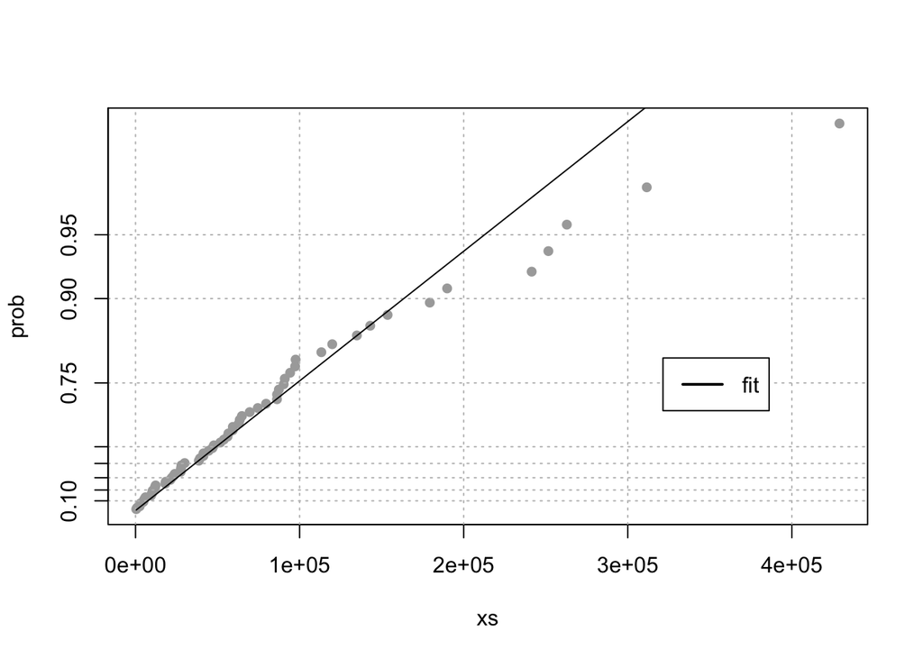

```r
expplot(width(betweenmotifs), rate = 1/mean(width(betweenmotifs)), labels = "fit")
```

While the points follow the line for a bit, they deviate for the largest values; this is likely due to the fact that protein coding sequences tend to “drop off” towards the end of genome.

### 2.10.1 Dependency Modeling using a *Markov chain*

Let’s look at Human chromosome 8 to see if there are difference between CpG islands, which are involved in gene expression/ regulation (i.e., epigenetics), and the remaining nucleotides.

```r
chr8 = Hsapiens$chr8 # Already loaded our library at the beginning
CpGtab = read.table("./data/model-based-cpg-islands-hg19.txt", header = TRUE) # Require addition function header = TRUE to load a text file
nrow(CpGtab)
```

```
## [1] 65699
```

```r
head(CpGtab)
```

```
##     chr  start    end length CpGcount GCcontent pctGC obsExp
## 1 chr10  93098  93818    721       32       403 0.559  0.572
## 2 chr10  94002  94165    164       12        97 0.591  0.841
## 3 chr10  94527  95302    776       65       538 0.693  0.702
## 4 chr10 119652 120193    542       53       369 0.681  0.866
## 5 chr10 122133 122621    489       51       339 0.693  0.880
## 6 chr10 180265 180720    456       32       256 0.561  0.893
```

Let’s filter the CpG data to only show chromosome 8 using *dplyr* and *IRanges*.

```r
irCpG = with(dplyr::filter(CpGtab, chr == "chr8"), IRanges(start = start, end = end))
irCpG
```

```
## IRanges object with 2855 ranges and 0 metadata columns:
##              start       end     width
##          <integer> <integer> <integer>
##      [1]     32437     33708      1272
##      [2]     40354     40656       303
##      [3]     44536     46203      1668
##      [4]     99457    100721      1265
##      [5]    155954    156761       808
##      ...       ...       ...       ...
##   [2851] 146126089 146128165      2077
##   [2852] 146175867 146176338       472
##   [2853] 146228006 146228907       902
##   [2854] 146232962 146233086       125
##   [2855] 146276730 146278360      1631
```

```r
vignette("IRangesOverview") # What does *IRanges* do?
```

*Note* - The “::” is used below to specifically call the “filter” function from dplyr

To visualize the CpG locations, let’s add biological context using *GRanges* and then make a *Gviz* plot

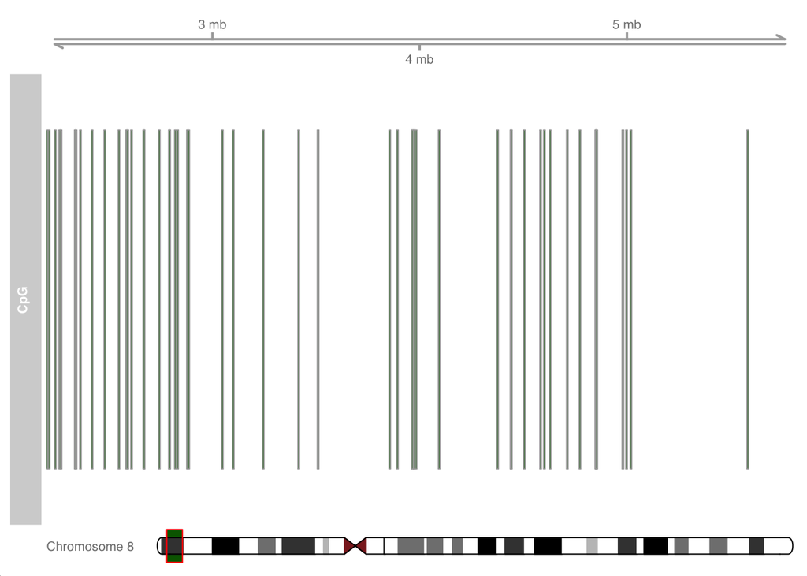

```r
grCpG = GRanges(ranges = irCpG, seqnames = "chr8", strand = "+")
genome(grCpG) = "hg19"
ideo = IdeogramTrack(genome = "hg19", chromosome = "chr8")
plotTracks(
  list(GenomeAxisTrack(),
       AnnotationTrack(grCpG, name = "CpG"), ideo),
  from = 2200000, to = 5800000, shape = "box", fill = "#006400", stacking = "dense"
)
```

We can then compute dinucleotide transition counts in both CpG and non-CpG regions.

```r
CGIview = Views(unmasked(Hsapiens$chr8), irCpG)
NonCGIview = Views(unmasked(Hsapiens$chr8), gaps(irCpG))
seqCGI = as(CGIview, "DNAStringSet")
seqNonCGI = as(NonCGIview, "DNAStringSet")
dinucCpG = sapply(seqCGI, dinucleotideFrequency)
dinucCpG[,1]
```

```
##  AA  AC  AG  AT  CA  CC  CG  CT  GA  GC  GG  GT  TA  TC  TG  TT
##  49 127  55   8 132  44 116 112  54 129 107 100   4 104 112  18
```

```r
dinucNonCpG = sapply(seqNonCGI, dinucleotideFrequency)
dinucNonCpG[,1]
```

```
##  AA  AC  AG  AT  CA  CC  CG  CT  GA  GC  GG  GT  TA  TC  TG  TT
## 389 351 400 436 498 560 112 603 359 336 403 336 330 527 519 485
```

Now let’s generate the fequencies…

```r
NonICounts = rowSums(dinucNonCpG)
IslCounts = rowSums(dinucCpG)
TI = matrix(IslCounts, ncol=4, byrow = T)
TnI = matrix(NonICounts, ncol=4, byrow =T)
dimnames(TI) = dimnames(TnI) = list(c("A", "C", "G", "T"), c("A", "C", "G", "T"))
MI = TI / rowSums(TI)
MI # dinucleotide transition probabilities in CpG islands
```

```
##            A         C         G         T
## A 0.20457773 0.2652333 0.3897678 0.1404212
## C 0.20128250 0.3442381 0.2371595 0.2173200
## G 0.18657245 0.3145299 0.3450223 0.1538754
## T 0.09802105 0.3352314 0.3598984 0.2068492
```

```r
MN = TnI / rowSums(TnI)
MN # dinucleotide transition probabilities not in CpG islands
```

```
##           A         C          G         T
## A 0.3351380 0.1680007 0.23080886 0.2660524
## C 0.3641054 0.2464366 0.04177094 0.3476871
## G 0.2976696 0.2029017 0.24655406 0.2528746
## T 0.2265813 0.1972407 0.24117528 0.3350027
```

**Question 2.24**

Do the transitions between the bases differ between rows? - Yes, they do; the frequency of a transition from an A to T is much different than, a C to T.

**Question 2.25**

Are the base frequencies different in CpG islands compared to everywhere else?

Let’s look at the frequencies within CpG islands…

```r
freqIsl = alphabetFrequency(seqCGI, baseOnly = TRUE, collapse = TRUE)[1:4]
freqIsl
```

```
##      A      C      G      T
## 313845 563875 564789 318990
```

```r
freqIsl / sum(freqIsl)
```

```
##         A         C         G         T
## 0.1781693 0.3201109 0.3206298 0.1810901
```

And now, the nucleotide frequencies elsewhere…

```r
freqNon = alphabetFrequency(seqNonCGI, baseOnly = T, collapse = T)[1:4]
freqNon / sum(freqNon)
```

```
##         A         C         G         T
## 0.3008292 0.1993832 0.1993737 0.3004139
```

As expected, we have higher frequencies of C and G within the CpG island than we do outside of this region.

**Question 2.26**

Use the $\chi^2$ statistic to compare the frequencies

How do we know if a particular sequence comes from a CpG island?

To deteremine the probability of a particular sequence residing in a CpG island, we can use the **log-likelihood ratio** score.

```r
alpha = log((freqIsl/sum(freqIsl)) / (freqNon/sum(freqNon)))
beta  = log(MI / MN)
```

```r
x = "ACGTTATACTACG"
scorefun = function(x) {
  s = unlist(strsplit(x, ""))
  score = alpha[s[1]]
  if (length(s) >= 2)
    for (j in 2:length(s))
      score = score + beta[s[j-1], s[j]]
  score
}
scorefun(x)
```

```
##          A
## -0.2824623
```

```r
generateRandomScores = function(s, len = 100, B = 1000) {
  alphFreq = alphabetFrequency(s)
  isGoodSeq = rowSums(alphFreq[, 5:ncol(alphFreq)]) == 0
  s = s[isGoodSeq]
  slen = sapply(s, length)
  prob = pmax(slen - len, 0)
  prob = prob / sum(prob)
  idx  = sample(length(s), B, replace = TRUE, prob = prob)
  ssmp = s[idx]
  start = sapply(ssmp, function(x) sample(length(x) - len, 1))
  scores = sapply(seq_len(B), function(i)
    scorefun(as.character(ssmp[[i]][start[i]+(1:len)]))
  )
  scores / len
}
scoresCGI    = generateRandomScores(seqCGI)
scoresNonCGI = generateRandomScores(seqNonCGI)
```

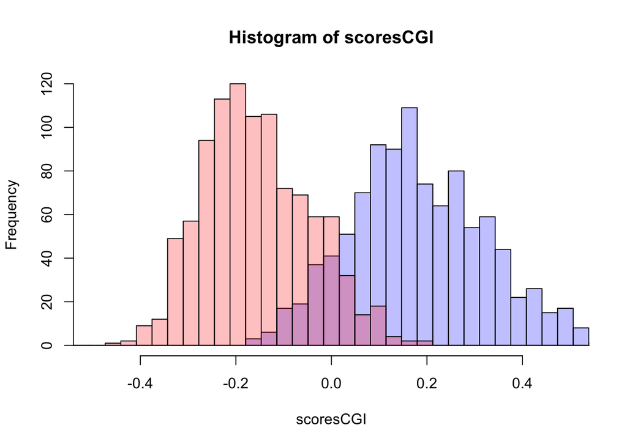

```r
br = seq(-0.8, 0.8, length.out = 50)
h1 = hist(scoresCGI,    breaks = br, plot = FALSE)
h2 = hist(scoresNonCGI, breaks = br, plot = FALSE)
plot(h1, col = rgb(0, 0, 1, 1/4), xlim = c(-0.5, 0.5), ylim=c(0,120))
plot(h2, col = rgb(1, 0, 0, 1/4), add = TRUE)
```

# Exercises

### 2.1 Generate 1,000 random 0/1 variables that model mutations occurring along a 1,000 long gene sequence. These occur independently at a rate of e-4 each. Then sum the 1,000 positions to count how many mutations in sequences of length 1,000.

```r
set.seed(123456789)
E2.1 = rbinom(1000, prob = 0.0001, size = 1000)
E2.1
```

```
##    [1] 0 0 0 0 1 0 0 1 0 0 0 0 0 0 0 0 0 0 0 0 0 0 0 0 0 0 0 0 0 0 0 0 0 0
##   [35] 0 0 0 0 0 0 0 0 0 0 0 0 0 0 0 0 0 0 0 0 0 0 0 0 0 0 0 2 0 0 0 0 0 1
##   [69] 0 0 0 0 0 0 0 0 0 0 0 0 0 0 0 0 0 0 0 0 1 0 0 1 0 0 0 0 0 0 0 0 0 0
##  [103] 0 0 1 0 0 0 0 0 0 0 0 0 1 0 0 0 1 0 0 0 0 0 0 1 0 0 0 0 0 0 0 0 1 0
##  [137] 0 0 0 0 0 0 0 0 0 0 0 0 0 0 0 0 0 0 0 0 0 0 0 0 0 0 0 0 1 0 0 0 0 0
##  [171] 0 0 0 0 0 0 0 0 0 0 0 0 0 0 0 0 0 0 0 0 0 0 0 0 1 0 0 0 0 0 0 0 0 0
##  [205] 0 0 0 0 0 0 0 0 0 0 0 0 0 1 0 0 0 0 0 0 1 0 0 0 0 0 0 0 0 0 0 0 0 0
##  [239] 0 1 1 0 0 0 0 0 0 0 0 0 0 0 0 0 0 0 0 0 1 0 0 0 0 0 0 0 1 0 0 0 0 0
##  [273] 0 0 0 0 0 0 0 0 0 0 1 0 0 0 0 0 0 0 1 0 0 0 0 0 0 0 0 0 0 0 0 0 0 0
##  [307] 0 0 0 0 0 0 0 0 0 0 1 0 0 0 0 0 1 0 0 0 0 0 0 0 0 0 0 0 0 0 0 0 0 0
##  [341] 0 0 0 0 0 0 0 0 0 0 0 0 0 1 1 0 0 0 0 0 0 0 0 0 0 0 0 0 1 0 1 0 0 0
##  [375] 0 0 0 0 0 0 0 0 0 0 0 0 0 0 0 0 0 0 0 0 1 0 0 0 0 0 0 0 1 0 0 0 0 0
##  [409] 1 0 0 0 0 0 0 0 0 0 0 0 0 0 0 0 0 0 0 0 0 0 0 0 1 0 0 0 0 0 0 0 0 1
##  [443] 0 0 0 0 0 0 0 0 0 0 0 0 0 0 0 0 0 0 0 0 0 0 0 0 0 0 0 0 1 0 0 0 2 0
##  [477] 0 0 0 0 0 0 0 0 0 0 0 0 1 0 0 0 0 0 0 0 0 0 0 0 0 0 0 0 0 0 0 0 1 0
##  [511] 0 0 0 0 0 0 0 0 0 0 0 0 0 1 0 1 0 0 0 1 0 0 1 0 0 0 0 0 0 0 0 0 1 0
##  [545] 0 0 0 0 0 1 1 0 0 0 0 0 0 1 0 1 0 0 0 0 0 0 0 0 0 1 0 0 0 0 0 0 0 0
##  [579] 0 0 0 0 0 0 0 0 0 0 0 0 0 0 0 0 0 0 0 0 0 1 0 0 0 0 0 0 0 0 0 0 1 0
##  [613] 0 0 0 0 0 0 1 0 0 0 0 0 0 0 0 0 0 0 0 0 0 1 0 0 0 0 1 0 0 0 0 0 0 0
##  [647] 0 0 1 0 0 1 1 0 0 0 0 0 0 0 0 0 0 0 0 0 0 0 0 0 0 0 0 0 0 0 0 0 0 0
##  [681] 0 0 0 0 0 0 0 0 0 0 0 0 0 0 0 0 0 0 0 0 0 0 0 0 0 0 0 0 0 0 0 1 0 0
##  [715] 0 0 0 0 0 0 0 0 0 0 0 0 0 0 0 0 1 0 1 0 0 0 0 0 0 1 0 0 0 0 1 0 1 0
##  [749] 0 1 0 0 0 0 0 0 0 0 0 0 1 1 0 0 0 0 0 0 0 0 0 0 1 0 0 0 0 1 1 1 0 0
##  [783] 0 0 0 0 0 0 0 0 1 0 0 0 0 0 0 0 0 0 0 0 0 0 0 0 1 0 0 0 0 0 0 0 0 0
##  [817] 0 0 0 0 0 0 0 0 1 0 0 0 0 0 0 0 1 0 1 0 0 1 0 0 0 0 0 0 0 0 0 0 1 0
##  [851] 1 0 0 0 0 0 0 2 0 0 0 0 0 0 0 0 0 1 0 0 0 0 0 0 0 0 0 0 0 1 0 0 1 1
##  [885] 0 0 0 0 0 0 0 0 0 0 0 0 0 0 0 1 0 1 0 0 0 0 0 0 0 0 0 1 0 1 0 0 0 0
##  [919] 0 0 0 0 0 0 0 0 0 1 0 0 0 0 0 0 0 0 0 0 1 0 0 0 0 0 0 0 0 0 0 0 0 0
##  [953] 0 0 0 0 0 0 0 0 0 0 0 0 0 0 0 0 0 0 0 0 0 0 0 0 0 0 0 0 0 0 0 0 0 0
##  [987] 0 0 0 0 0 0 0 0 0 0 2 0 1 0
```

```r
sum(E2.1 == 1) # count the number of mutations
```

```
## [1] 84
```

```r
gf = goodfit(E2.1, type = "poisson")
gf
```

```
##
## Observed and fitted values for poisson distribution
## with parameters estimated by `ML'
##
##  count observed     fitted pearson residual
##      0      912 912.105150     -0.003481649
##      1       84  83.913674      0.009423809
##      2        4   3.860029      0.009433875
```

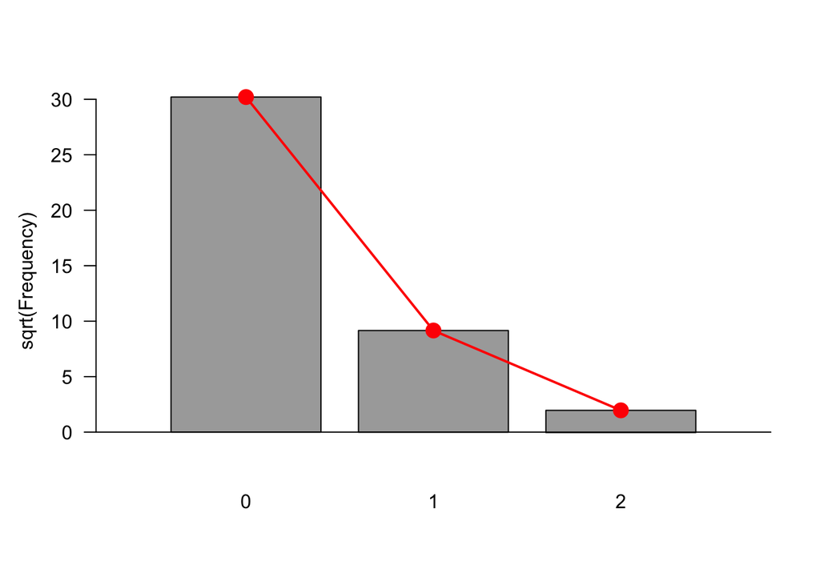

```r
rootogram(gf, xlab = "", rect_gp = gpar(fill = "darkgrey"))
```

### 2.2 Make a function that generates n random uniform numbers between 0 and 7 and returns their maximum. Then execute the function for n = 25 and repeat the procedure B = 100 times. Plot the distribution.

```r
RN = function(n) {
  runif(n, min = 0, max = 7) %>% which.max
}
set.seed(122)
RN(25)
```

```
## [1] 11
```

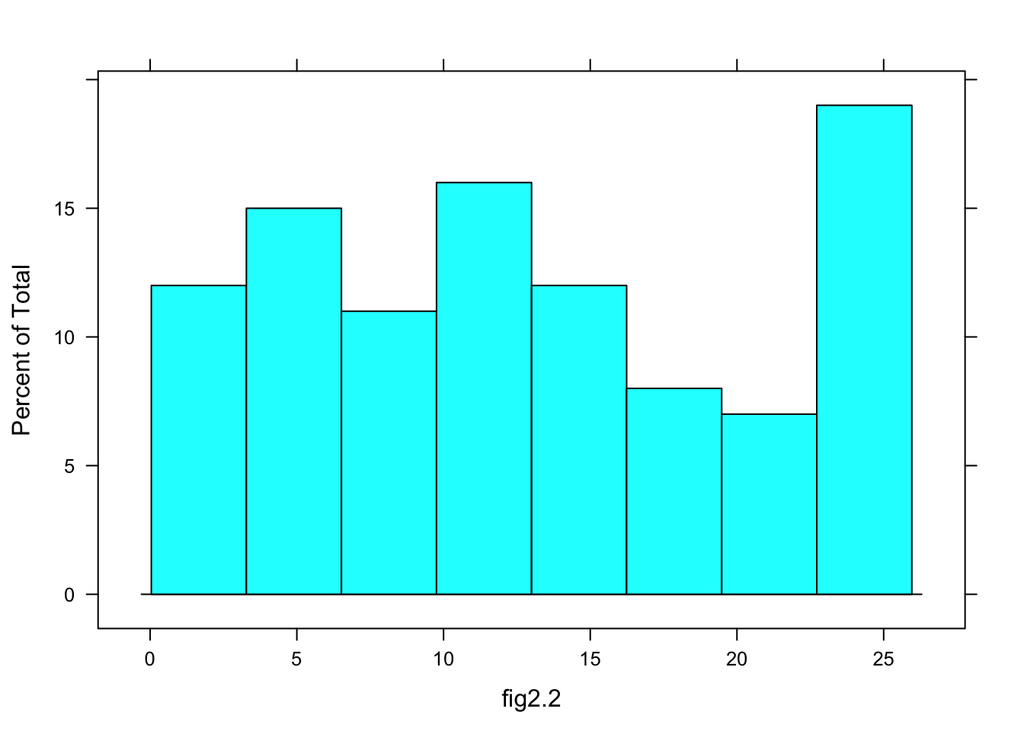

```r
fig2.2 = (replicate(100, RN(25)))
histogram(fig2.2)
```

What is the maximum likelihood estimate of the maximum of a sample of size 25?

…Not entirely sure how to do this, but seems similar to the example on page 23?

```r
m2.2 = mean(fig2.2)
m2.2
```

```
## [1] 12.95
```

```r
?goodfit
```

Can you find a theoretical justification and the true maximum theta?

…Not too sure

### Exercise 2.3

Load the Mtb data

```r
mtb = read.table("./data/M_tuberculosis.txt", header = TRUE)
mtb
```

```
##    AmAcid Codon Number PerThous
## 1     Gly   GGG  25874    19.25
## 2     Gly   GGA  13306     9.90
## 3     Gly   GGT  25320    18.84
## 4     Gly   GGC  68310    50.82
## 5     Glu   GAG  41103    30.58
## 6     Glu   GAA  21767    16.19
## 7     Asp   GAT  21165    15.75
## 8     Asp   GAC  56687    42.17
## 9     Val   GTG  53942    40.13
## 10    Val   GTA   6372     4.74
## 11    Val   GTT  10768     8.01
## 12    Val   GTC  43909    32.66
## 13    Ala   GCG  65402    48.65
## 14    Ala   GCA  17268    12.85
```

[output cut: 50 more lines]

```r
head(mtb, n = 4)
```

```
##   AmAcid Codon Number PerThous
## 1    Gly   GGG  25874    19.25
## 2    Gly   GGA  13306     9.90
## 3    Gly   GGT  25320    18.84
## 4    Gly   GGC  68310    50.82
```

Let’s look at the codon frequencies of Proline

```r
pro = mtb[mtb$AmAcid == "Pro", "Number"]
pro/sum(pro)
```

```
## [1] 0.54302025 0.10532985 0.05859765 0.29305225
```

1. Explore the data mtb using table to tabulate the AmAcid and Codon variables.

```r
mtbAA = table(mtb$AmAcid, mtb$Codon)
mtbAA
```

```
##
##       AAA AAC AAG AAT ACA ACC ACG ACT AGA AGC AGG AGT ATA ATC ATG ATT CAA
##   Ala   0   0   0   0   0   0   0   0   0   0   0   0   0   0   0   0   0
##   Arg   0   0   0   0   0   0   0   0   1   0   1   0   0   0   0   0   0
##   Asn   0   1   0   1   0   0   0   0   0   0   0   0   0   0   0   0   0
##   Asp   0   0   0   0   0   0   0   0   0   0   0   0   0   0   0   0   0
##   Cys   0   0   0   0   0   0   0   0   0   0   0   0   0   0   0   0   0
##   End   0   0   0   0   0   0   0   0   0   0   0   0   0   0   0   0   0
##   Gln   0   0   0   0   0   0   0   0   0   0   0   0   0   0   0   0   1
##   Glu   0   0   0   0   0   0   0   0   0   0   0   0   0   0   0   0   0
##   Gly   0   0   0   0   0   0   0   0   0   0   0   0   0   0   0   0   0
##   His   0   0   0   0   0   0   0   0   0   0   0   0   0   0   0   0   0
##   Ile   0   0   0   0   0   0   0   0   0   0   0   0   1   1   0   1   0
##   Leu   0   0   0   0   0   0   0   0   0   0   0   0   0   0   0   0   0
##   Lys   1   0   1   0   0   0   0   0   0   0   0   0   0   0   0   0   0
##   Met   0   0   0   0   0   0   0   0   0   0   0   0   0   0   1   0   0
##   Phe   0   0   0   0   0   0   0   0   0   0   0   0   0   0   0   0   0
##   Pro   0   0   0   0   0   0   0   0   0   0   0   0   0   0   0   0   0
##   Ser   0   0   0   0   0   0   0   0   0   1   0   1   0   0   0   0   0
##   Thr   0   0   0   0   1   1   1   1   0   0   0   0   0   0   0   0   0
##   Trp   0   0   0   0   0   0   0   0   0   0   0   0   0   0   0   0   0
##   Tyr   0   0   0   0   0   0   0   0   0   0   0   0   0   0   0   0   0
##   Val   0   0   0   0   0   0   0   0   0   0   0   0   0   0   0   0   0
##
##       CAC CAG CAT CCA CCC CCG CCT CGA CGC CGG CGT CTA CTC CTG CTT GAA GAC
##   Ala   0   0   0   0   0   0   0   0   0   0   0   0   0   0   0   0   0
##   Arg   0   0   0   0   0   0   0   1   1   1   1   0   0   0   0   0   0
##   Asn   0   0   0   0   0   0   0   0   0   0   0   0   0   0   0   0   0
##   Asp   0   0   0   0   0   0   0   0   0   0   0   0   0   0   0   0   1
##   Cys   0   0   0   0   0   0   0   0   0   0   0   0   0   0   0   0   0
##   End   0   0   0   0   0   0   0   0   0   0   0   0   0   0   0   0   0
##   Gln   0   1   0   0   0   0   0   0   0   0   0   0   0   0   0   0   0
##   Glu   0   0   0   0   0   0   0   0   0   0   0   0   0   0   0   1   0
##   Gly   0   0   0   0   0   0   0   0   0   0   0   0   0   0   0   0   0
##   His   1   0   1   0   0   0   0   0   0   0   0   0   0   0   0   0   0
##   Ile   0   0   0   0   0   0   0   0   0   0   0   0   0   0   0   0   0
##   Leu   0   0   0   0   0   0   0   0   0   0   0   1   1   1   1   0   0
##   Lys   0   0   0   0   0   0   0   0   0   0   0   0   0   0   0   0   0
##   Met   0   0   0   0   0   0   0   0   0   0   0   0   0   0   0   0   0
##   Phe   0   0   0   0   0   0   0   0   0   0   0   0   0   0   0   0   0
```

[output cut: 37 more lines]

```
##   Gln   0   0   0   0   0   0   0   0   0   0   0   0   0
##   Glu   0   0   0   0   0   0   0   0   0   0   0   0   0
##   Gly   0   0   0   0   0   0   0   0   0   0   0   0   0
##   His   0   0   0   0   0   0   0   0   0   0   0   0   0
##   Ile   0   0   0   0   0   0   0   0   0   0   0   0   0
##   Leu   0   0   0   0   0   0   0   0   0   1   0   1   0
##   Lys   0   0   0   0   0   0   0   0   0   0   0   0   0
##   Met   0   0   0   0   0   0   0   0   0   0   0   0   0
##   Phe   0   0   0   0   0   0   0   0   0   0   1   0   1
##   Pro   0   0   0   0   0   0   0   0   0   0   0   0   0
##   Ser   0   1   1   1   1   0   0   0   0   0   0   0   0
##   Thr   0   0   0   0   0   0   0   0   0   0   0   0   0
##   Trp   0   0   0   0   0   0   0   1   0   0   0   0   0
##   Tyr   1   0   0   0   0   0   0   0   0   0   0   0   0
##   Val   0   0   0   0   0   0   0   0   0   0   0   0   0
```

```r
table(mtb$AmAcid)
```

```
##
## Ala Arg Asn Asp Cys End Gln Glu Gly His Ile Leu Lys Met Phe Pro Ser Thr
##   4   6   2   2   2   3   2   2   4   2   3   6   2   1   2   4   6   4
## Trp Tyr Val
##   1   2   4
```

```r
table(mtb$Codon) %>% sum()
```

```
## [1] 64
```

2. How was the PerThous variable created?

```r
mtb$Number / mtb$PerThous
```

```
##  [1] 1344.104 1344.040 1343.949 1344.156 1344.114 1344.472 1343.810
##  [8] 1344.249 1344.181 1344.304 1344.320 1344.427 1344.337 1343.813
## [15] 1343.813 1344.335 1343.574 1348.837 1345.763 1344.061 1344.238
## [22] 1343.454 1343.856 1344.199 1344.221 1341.818 1344.582 1344.084
## [29] 1343.890 1345.154 1345.777 1344.343 1343.912 1346.914 1343.694
## [36] 1344.646 1347.727 1340.426 1343.586 1343.981 1344.506 1344.444
## [43] 1344.084 1344.368 1344.525 1345.915 1344.144 1344.281 1344.029
## [50] 1344.167 1344.142 1344.268 1344.137 1343.580 1344.704 1344.220
## [57] 1344.103 1345.359 1344.669 1344.123 1344.233 1344.608 1342.522
## [64] 1344.392
```

The variable was created….by dividing by 1344; however, not exactly sure of the significance of this number?

3. Write an R function that you can apply to the table to find which of the amino acids shows the strongest codon bias, i.e., the strongest departure from uniform distribution among its possible spellings.

```r
codonbias <- function(aa){
  #choose aa
  aa_table <- mtb %>% as_tibble %>% filter(mtb$AmAcid == aa)

  #add observed frequencies of codon usage by factoring total counts
  aa_table <- mutate(aa_table, obs_freq = aa_table$Number / sum(aa_table$Number))

  #add expected frequency based on 1/number of codons
  aa_table <- mutate(aa_table, exp_freq = 1/nrow(aa_table))

  #find the difference between observed and expected frequencies
  aa_table <- mutate(aa_table, usage_diff = obs_freq - exp_freq)

  print(aa_table)
  row_max <- which.max(abs(aa_table$usage_diff))

  #required if the bias is AGAINST using a codon
  if(nrow(aa_table) > 2 && aa_table$usage_diff[row_max] < 0){
    print("Codon bias against, aka bias towards not using it")
    print(aa_table$Codon[row_max])
  }

  #requied if the bias is FOR using a codon
  else if (nrow(aa_table) > 2 && aa_table$usage_diff[row_max] > 0){
    print("Codon bias for, aka bias towards using it")
    print(aa_table$Codon[row_max])
  }

  #two codons availble means equal bias for/against
  else if (nrow(aa_table) == 2) {
    print("Only two available codons, usage for both codons deviates the same, equal bias")
    print(aa_table$Codon)
  }

  #one codon available means no bias possible
  else if (nrow(aa_table) == 1){
    print("Only one available codon")
  }
}
```

```r
codonbias("Leu")
```

```
## # A tibble: 6 x 7
##   AmAcid Codon Number PerThous obs_freq exp_freq usage_diff
##   <fct>  <fct>  <int>    <dbl>    <dbl>    <dbl>      <dbl>
## 1 Leu    TTG    24107    17.9    0.184     0.167     0.0174
## 2 Leu    TTA     2178     1.62   0.0166    0.167    -0.150
## 3 Leu    CTG    67810    50.4    0.518     0.167     0.351
## 4 Leu    CTA     6377     4.74   0.0487    0.167    -0.118
## 5 Leu    CTT     7315     5.44   0.0558    0.167    -0.111
## 6 Leu    CTC    23213    17.3    0.177     0.167     0.0105
## [1] "Codon bias for, aka bias towards using it"
## [1] CTG
## 64 Levels: AAA AAC AAG AAT ACA ACC ACG ACT AGA AGC AGG AGT ATA ATC ... TTT
```

```r
codonbias2 <- function(){
  #prime with stop codon
  stop_table <- mtb %>% as_tibble %>% filter(mtb$AmAcid == "End")

  #finding observed frequencies for end
  stop_table <- mutate(stop_table, obs_freq = stop_table$Number / sum(stop_table$Number))

  #add expected frequency based on 1/number of codons
  stop_table <- mutate(stop_table, exp_freq = 1/nrow(stop_table))

  #find the difference between observed and expected frequencies
  stop_table <- mutate(stop_table, usage_diff = obs_freq - exp_freq)

  #aa vector
  aas <- c("Gly", "Glu", "Asp", "Val", "Ala", "Pro", "Leu", "Ile", "His", "Gln", "Arg", "Ser", "Phe", "Tyr", "Cys", "Thr", "Asn", "Lys", "Val")

  #add observed frequencies of codon usage by factoring total counts for all aas not stop
  for (query_aa in aas){
  each_aa_table <- mtb %>% as_tibble %>% filter(mtb$AmAcid == query_aa)

  #finding observed frequencies for aas
  each_aa_table <- mutate(each_aa_table, obs_freq = each_aa_table$Number / sum(each_aa_table$Number))

  #add expected frequency based on 1/number of codons
  each_aa_table <- mutate(each_aa_table, exp_freq = 1/nrow(each_aa_table))

  #find the difference between observed and expected frequencies
  each_aa_table <- mutate(each_aa_table, usage_diff = obs_freq - exp_freq)

  #add table back to aa_table
  stop_table <- full_join(stop_table, each_aa_table, by = c("AmAcid", "Codon", "Number", "PerThous", "obs_freq", "exp_freq", "usage_diff"))
  }

  stop_table %>%  print(n = Inf)
  row_max <- which.max(stop_table$usage_diff)
  print("Bias for")
  print(stop_table$Codon[row_max])
  row_min <- which.min(stop_table$usage_diff)
  print("Bias against")
  print(stop_table$Codon[row_min])
}
```

```r
codonbias2()
```

```
## # A tibble: 62 x 7
##    AmAcid Codon Number PerThous obs_freq exp_freq usage_diff
##    <fct>  <fct>  <int>    <dbl>    <dbl>    <dbl>      <dbl>
##  1 End    TGA     2182     1.62   0.546     0.333     0.212
##  2 End    TAG     1186     0.88   0.297     0.333    -0.0367
##  3 End    TAA      630     0.47   0.158     0.333    -0.176
##  4 Gly    GGG    25874    19.2    0.195     0.25     -0.0552
##  5 Gly    GGA    13306     9.9    0.100     0.25     -0.150
##  6 Gly    GGT    25320    18.8    0.191     0.25     -0.0594
##  7 Gly    GGC    68310    50.8    0.514     0.25      0.264
##  8 Glu    GAG    41103    30.6    0.654     0.5       0.154
##  9 Glu    GAA    21767    16.2    0.346     0.5      -0.154
## 10 Asp    GAT    21165    15.8    0.272     0.5      -0.228
## 11 Asp    GAC    56687    42.2    0.728     0.5       0.228
## 12 Val    GTG    53942    40.1    0.469     0.25      0.219
```

[output cut: 56 more lines]

### 2.4 Display GC content in a running window along the sequence of Staphylococcus aureus.

1. Look at the complete staph object and then display the first three sequences in the set.

```r
staph = readDNAStringSet("./data/staphsequence.ffn.txt", "fasta")
str(staph)
```

```
## Formal class 'DNAStringSet' [package "Biostrings"] with 5 slots
##   ..@ pool           :Formal class 'SharedRaw_Pool' [package "XVector"] with 2 slots
##   .. .. ..@ xp_list                    :List of 1
##   .. .. .. ..$ :<externalptr>
##   .. .. ..@ .link_to_cached_object_list:List of 1
##   .. .. .. ..$ :<environment: 0x7fae7e30d538>
##   ..@ ranges         :Formal class 'GroupedIRanges' [package "XVector"] with 7 slots
##   .. .. ..@ group          : int [1:2650] 1 1 1 1 1 1 1 1 1 1 ...
##   .. .. ..@ start          : int [1:2650] 1 1363 2497 2743 3856 5788 8449 9280 10795 12082 ...
##   .. .. ..@ width          : int [1:2650] 1362 1134 246 1113 1932 2661 831 1515 1287 696 ...
##   .. .. ..@ NAMES          : chr [1:2650] "lcl|NC_002952.2_cdsid_YP_039478.1 [gene=dnaA] [protein=chromosomal replication initiation protein] [protein_id="| __truncated__ "lcl|NC_002952.2_cdsid_YP_039479.1 [gene=dnaN] [protein=DNA polymerase III subunit beta] [protein_id=YP_039479.1"| __truncated…
##   .. .. ..@ elementType    : chr "ANY"
##   .. .. ..@ elementMetadata: NULL
##   .. .. ..@ metadata       : list()
##   ..@ elementType    : chr "DNAString"
##   ..@ elementMetadata: NULL
##   ..@ metadata       : list()
```

```r
length(staph)
```

```
## [1] 2650
```

```r
staph[1:3] # look at the first 3 sequences
```

```
##   A DNAStringSet instance of length 3
##     width seq                                          names
## [1]  1362 ATGTCGGAAAAAGAAATTTGG...AAGAAATAAGAAATGTATAA lcl|NC_002952.2_c...
## [2]  1134 ATGATGGAATTCACTATTAAA...TACCAATCAGAACTTACTAA lcl|NC_002952.2_c...
## [3]   246 GTGATTATTTTGGTTCAAGAA...TTCATCAAGGTGAACAATGA lcl|NC_002952.2_c...
```

2. Find the GC content in sequence windows of width 100.

```r
Nuc_sum = letterFrequency(staph, letters="ACGT", OR=0) # view letter frequency across all sequences
window = 100 # compute the GC content in a sliding window (as a fraction)
gc = letterFrequencyInSlidingView(staph[[364]], 100, "GC")
gc %>% as_tibble %>% print(n=20)
```

```
## # A tibble: 303 x 1
##    `G|C`
##    <int>
##  1    40
##  2    40
##  3    40
##  4    40
##  5    41
##  6    41
##  7    40
##  8    39
##  9    39
## 10    40
## 11    39
## 12    39
## 13    39
## 14    39
## 15    39
## 16    39
## 17    39
## 18    39
## 19    39
## 20    39
## # … with 283 more rows
```

3. Display the GC content in a sliding window as a fraction.

```r
table(gc)
```

```
## gc
## 27 28 29 30 31 32 33 34 35 36 37 38 39 40 41 42 43 44
##  1  3  1  1  5  6  1  1  1 12 56 75 59 38 15 16  6  6
```

```r
gc_freq = gc / window # compute frequencies
gc_freq %>% as_tibble %>% print(n=20)
```

```
## # A tibble: 303 x 1
##    `G|C`
##    <dbl>
##  1  0.4
##  2  0.4
##  3  0.4
##  4  0.4
##  5  0.41
##  6  0.41
##  7  0.4
##  8  0.39
##  9  0.39
## 10  0.4
## 11  0.39
## 12  0.39
## 13  0.39
## 14  0.39
## 15  0.39
## 16  0.39
## 17  0.39
## 18  0.39
## 19  0.39
## 20  0.39
## # … with 283 more rows
```

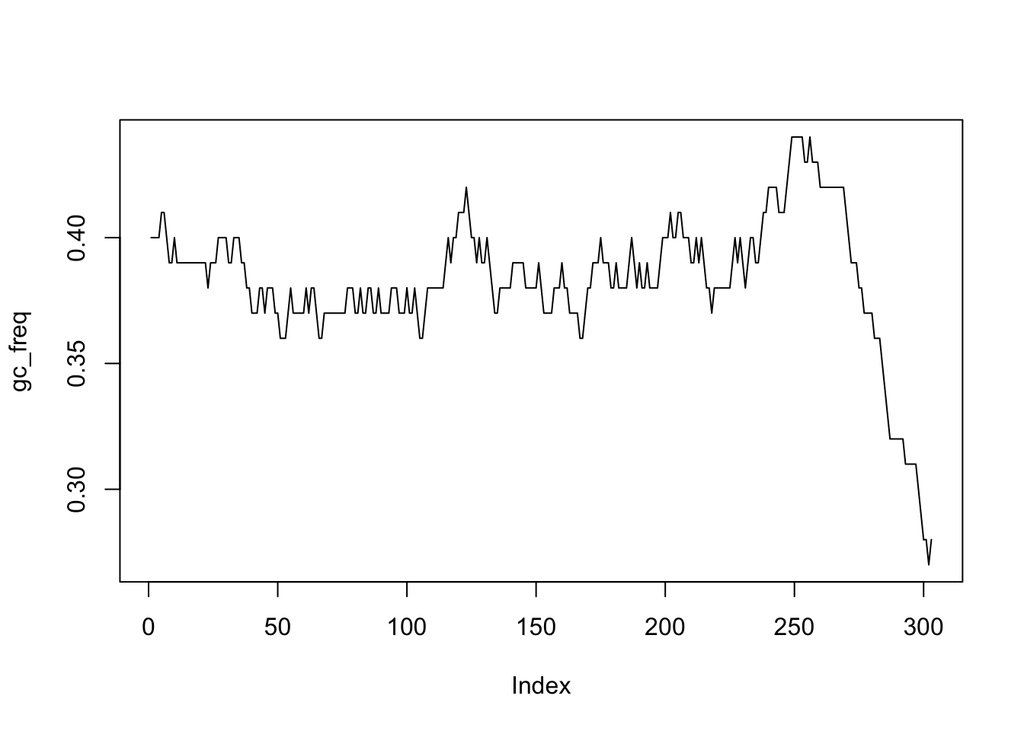

```r
plot(gc_freq, type = "l") # make a plot
```

4. How could we visualize the overall trends of these proportions along the sequence?

We could visualize the overall trends by adding a smooth line?

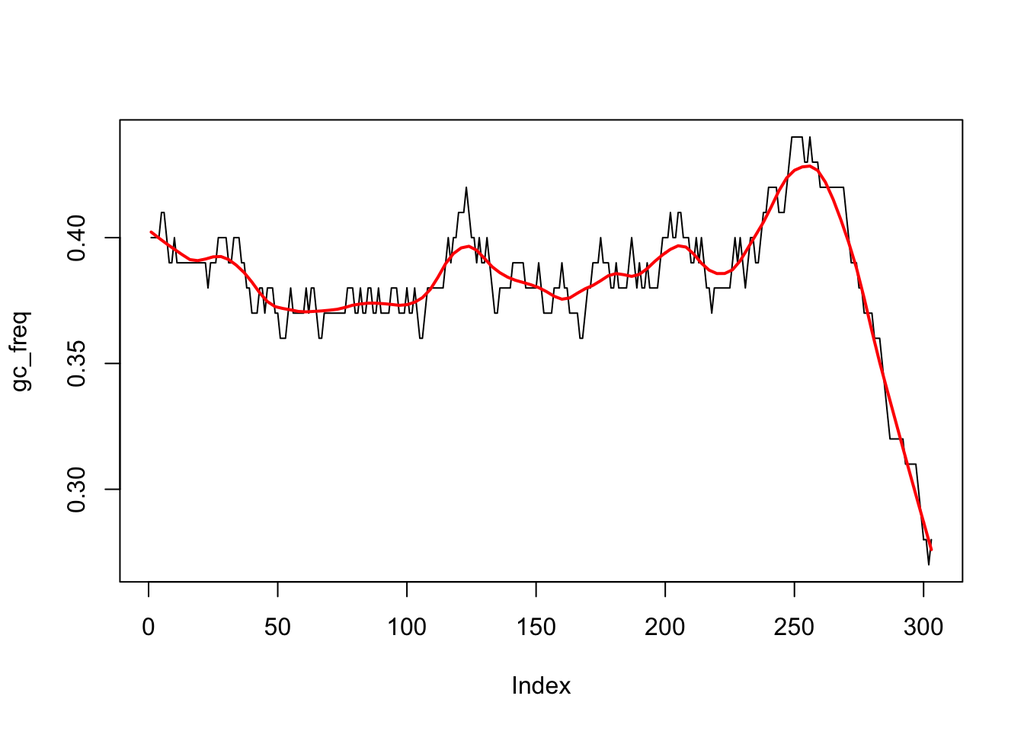

```r
plot(gc_freq, type = "l")
?lowess # function for smoothing
lines(lowess(x = 1:length(gc_freq), y= gc_freq, f = 0.1), col = "red", lwd = 2)
```

### 2.5 Redo a figure similar to Figure 2.17, but include two other distributions: the uniform (which is B(1,1)) and the B(1/2, 1/2).

```r
theta = thetas[1:1000]
dfbetas = data.frame(theta,
           db1 = dbeta(theta,1,1),
           db2 = dbeta(theta,0.5,0.5),
           db3 = dbeta(theta,10,30),
           db4 = dbeta(theta,20,60),
           db5 = dbeta(theta,50,150))
          require(reshape2)
```

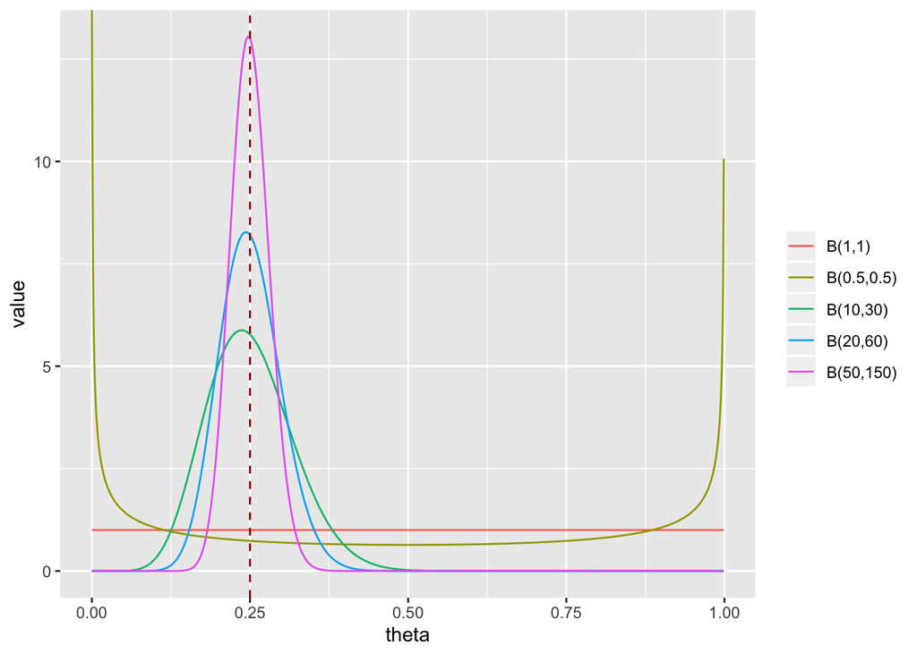

```r
datalong  =  melt(dfbetas, id="theta")
ggplot(datalong) +
geom_line(aes(x = theta,y=value,colour=variable)) +
theme(legend.title=element_blank()) +
geom_vline(aes(xintercept=0.25), colour="#990000", linetype="dashed")+
scale_colour_discrete(name  ="Prior",
                          labels=c("B(1,1)", "B(0.5,0.5)",
                                   "B(10,30)", "B(20,60)","B(50,150)"))
```

*Note* - The beta distribution represents all the possible values of a probability when we don’t know what that probability is (i.e., a probability distribution of probabilities).

### 2.6 Re-analyse the data from Section 2.9.2 using a sketched prior.

Using the shiny app, https://jhubiostatistics.shinyapps.io/drawyourprior/, the prior were calculated to be $\alpha$ = 4, $\beta$ = 5

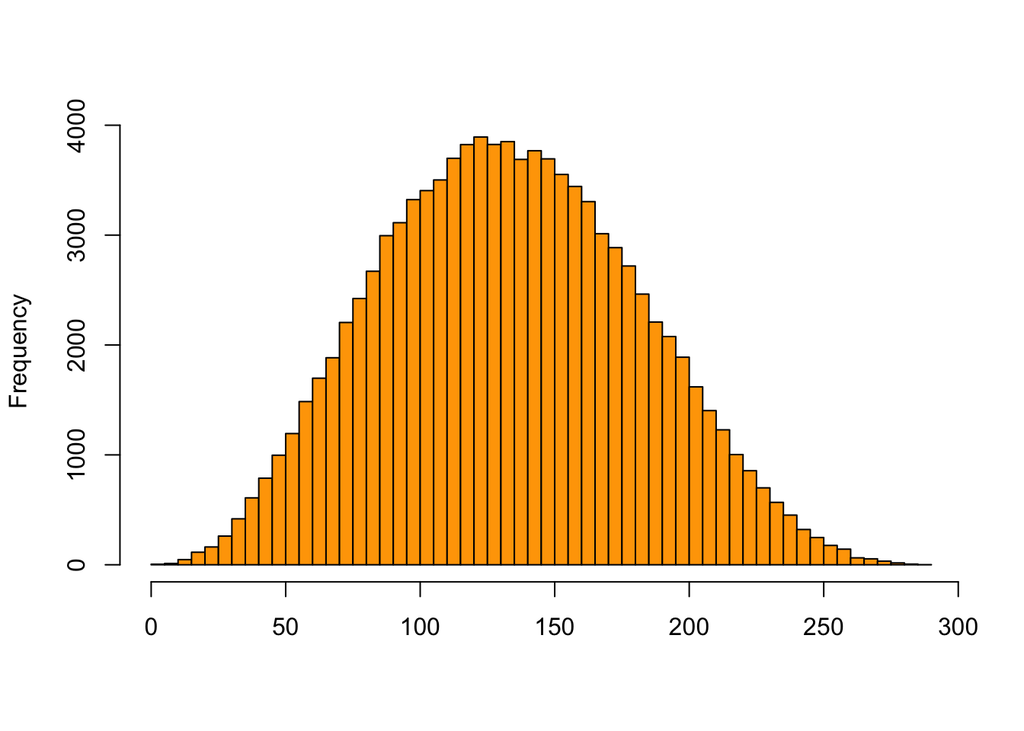

```r
rtheta = rbeta(100000, 4, 5)
y = vapply(rtheta, function(th) {
  rbinom(1, prob=th, size=300)
}, numeric(1))
hist(y, breaks =50, col ="orange", main= "", xlab = "")
```

The posterior parameters are $\alpha$ = 44, $\beta$ = 265

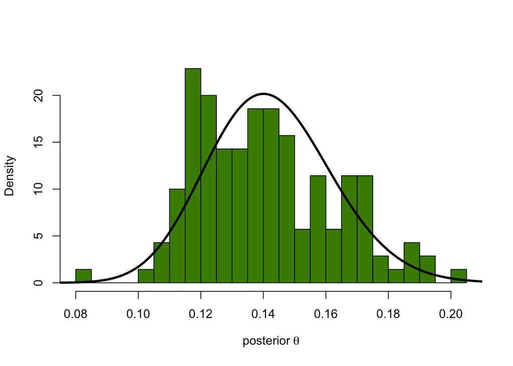

```r
thetas = seq(0, 1, by = 0.001) # vector from pg. 26
thetaPostEmp = rtheta[ y == 40 ]
hist(thetaPostEmp, breaks = 40, col = "chartreuse4", main = "",
  probability = TRUE, xlab = expression("posterior"~theta))
densPostTheory  =  dbeta(thetas, 44, 265)
lines(thetas, densPostTheory, type="l", lwd = 3)
```

Now let’s check the means of both distributions.

```r
mean(thetaPostEmp)
```

```
## [1] 0.1404471
```

```r
dtheta = thetas[2]-thetas[1]
sum(thetas * densPostTheory * dtheta)
```

```
## [1] 0.1423948
```

We can use Monte Carlo Integration to compute the posterior mean.

```r
thetaPostMC = rbeta(n=100000, 44, 265)
mean(thetaPostMC)
```

```
## [1] 0.1423494
```

Let’s check the concordance between the Monte Carlo sample and our sample using a QQ-plot.

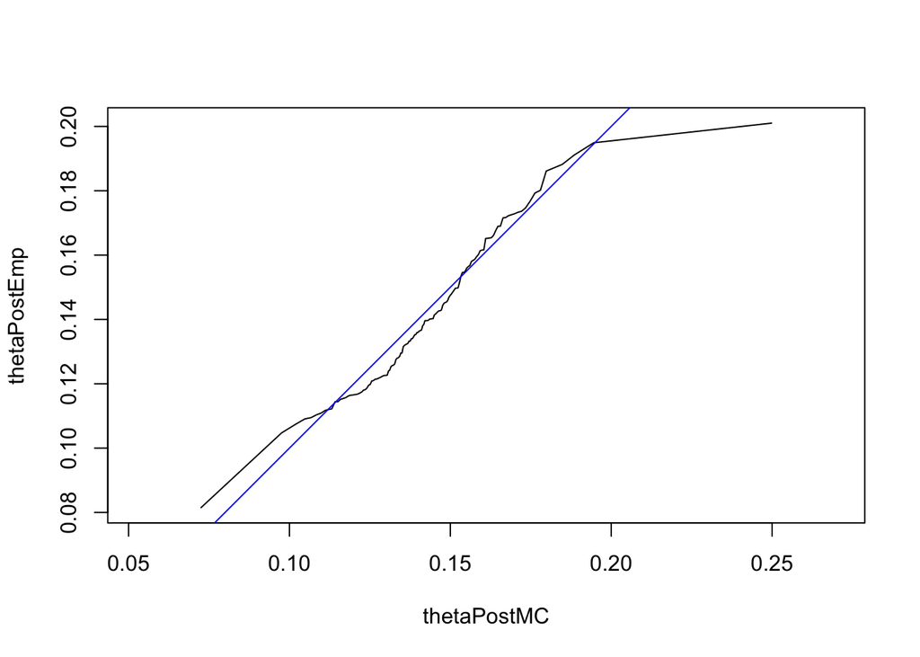

```r
qqplot(thetaPostMC, thetaPostEmp, type = "l", asp = 1)
abline(a = 0, b= 1, col="blue")
```